# From Pre-Paradigmatic to Constructive Science

How AMTAIR Could Transform AI Governance Through Evolutionary Intervention Design

Author

Valentin Jakob Meyer

Published

December 31, 2025

Abstract

AI safety and governance remain trapped in what Kuhn (1962) would immediately recognize as a pre-paradigmatic state: multiple incompatible frameworks compete, fundamental concepts remain contested, and each researcher begins from first principles rather than building on shared foundations. Despite recent interest intensifying and funding pouring in, the field lacks the basic infrastructure of normal science — shared methods, standard exemplars, and cumulative progress mechanisms. This paper argues that AMTAIR (Automated Modeling of Transformative AI Risks) — a computational system for extracting formal probabilistic models from natural language arguments — could catalyze the field’s transition to paradigmatic science by transforming discourse from a “persuasion game” to an “accuracy game”. Through an evolutionary analysis of AI safety discourse, I demonstrate how current selection pressures systematically favor memetically fit arguments over epistemically accurate ones, creating information cascades and coordination failures. AMTAIR intervenes in these dynamics by making implicit models explicit, enabling systematic comparison, decomposing disagreements into empirical and normative components, and creating accountability through prediction tracking.

Drawing on recent advances in large language model (LLM)-based argument extraction (Buckingham Shum, 2024), formal dispute resolution (Prokudin et al., 2024), and policy discourse visualization (Bhatia & Sukthankar, 2024), alongside Hendrycks (2023)’s evolutionary framework for AI development, I show how strategic deployment of AMTAIR could shift selection pressures toward accuracy — and why the risks of formalization “theater” and technocratic capture, though real, are structurally addressable.

Keywords

AI governance, paradigm formation, evolutionary epistemology, Bayesian networks, argument extraction, information cascades, cultural evolution, AI safety, collective intelligence

## I. Introduction: Diagnosing Pre-Paradigmatic Improvisation

What would count as sufficient evidence that a frontier AI system is safe to deploy publicly? One researcher demands formal verification of alignment properties. Another requires actuarial data from deployment at scale — thereby reversing the burden of proof by presupposing the very deployment in question. A third insists safety is an institutional question: organizational frameworks determine acceptable risk, not technical benchmarks. A fourth argues that “safety guarantees” are the wrong framing entirely — the question is whether the system’s capability trajectory permits human correction of errors. These are not merely different answers to the same question. They are answers to different questions, each presupposing a different causal model of what makes AI dangerous. No shared framework exists for determining which question deserves priority.

AI capabilities are advancing at exponential rates — frontier models now write code, conduct research, and engage in strategic planning — yet our collective ability to govern these systems remains trapped in what Kuhn (1962) would recognize as a pre-paradigmatic state.[^1] Multiple incompatible frameworks compete without resolution, fundamental concepts remain contested, and each researcher begins from first principles rather than building on shared foundations. This is not merely an “early-stage field” finding its footing — it exhibits the specific structural pathologies Kuhn documented in pre-paradigmatic astronomy, chemistry, and early electricity research.

AI governance operates across multiple epistemic layers — empirical questions about capabilities and trajectories, modeling questions about causal mechanisms, policy questions about institutional interventions, and normative questions about values and priorities. This paper targets the empirical and modeling dimensions.

However, the pre-paradigmatic state is also a window of opportunity, not merely a diagnosis. If AI governance locks in a paradigm based on current prestige dynamics — where memetic fitness trumps epistemic accuracy — the costs of later correction become painful. Kuhn documented how entrenched paradigms resist revision even when anomalies accumulate; in AI governance, where the stakes include existential risks, a paradigm locked in by prestige rather than accuracy could misdirect vast resources and distort regulatory frameworks based on models that happen to be vivid rather than correct. History supports the intuition that paradigms are easier to shape during formation than to reform after consolidation. AMTAIR (Automated Modeling of Transformative AI Risks), a computational system for extracting formal probabilistic models from natural language arguments, could provide the infrastructure needed for robust paradigm formation.[^2]

Drawing on Kuhn’s (1962, Ch. II) diagnostic framework, this paper identifies several symptoms distinguishing pre-paradigmatic fields from mature sciences.[^3] AI safety exhibits:

**No dominant paradigm**: Fundamental splits exist not just over predictions but over entire causal structures and conceptual frameworks. Bostrom’s (2014) intelligence explosion framework, Christiano’s (2018) prosaic alignment agenda, and Hanson’s (2013) market-based approaches represent incompatible world-models. They don’t merely disagree on parameter values — they disagree on what variables matter, what causal mechanisms operate, what epistemic standards to value and what evidence is relevant. Often researchers cannot even pinpoint their disagreement precisely, because they lack shared structures for comparison.

**Competing schools**: Researchers regularly self-sort into communities (LessWrong, EA Forum, academic AI safety, industry labs) that often reinforce rather than challenge core assumptions. Cross-community engagement is rare and often hostile rather than constructive.

**Fundamental debates**: Continuous debates about definitions[^4] such as argument over what “AGI,” “alignment,” and “agency” even mean prevent standardization. Most papers re-establish basic terminology from scratch, a hallmark Kuhn identified in pre-paradigmatic fields.

**No normal science**: No shared paradigm defines legitimate puzzles or acceptable solutions, so most researchers begin from first principles rather than extending established results.[^5]

The evidence is substantial: $P(\text{doom})$ estimates span from <1% (e.g., Hanson) to >98% (e.g., Yudkowsky) across researchers with relevant technical or governance expertise; AGI timeline predictions range from “already here” to “never”; preferred governance approaches vary from international treaties to laissez-faire to civilizational pause (Grace et al., 2018; Müller & Bostrom, 2016). This isn’t healthy disagreement-within-paradigm, it’s the chaos Kuhn describes *before* paradigm formation.

What makes AI governance’s pre-paradigmatic condition distinctively dangerous — and distinctively resistant to self-correction — is a dual pathology. Unlike natural sciences, where experimental feedback selects for more predictively accurate theories over time, AI governance’s existing selection mechanisms are insufficient to significantly favor frameworks that track reality.[^6] Peer review, citation norms, and replication norms exist but are overwhelmed by the scale and speed of the field; the mechanisms that *do* exert strong selection — prestige hierarchies, memetic fitness, funding incentives, coalition dynamics — actively favor persuasiveness over precision. The field doesn’t merely have weak compasses; its strongest compasses systematically point away from true north.

These same features help to explain why these conditions resist correction: knowledge producers lack shared institutional norms and span incommensurable disciplinary cultures (rationalist blogs, computer science departments, philosophy, political science, industry labs, think tanks, government agencies) with no widely agreed-on standards of evidence; the object of study transforms faster than frameworks can track, creating moving-target dynamics; the stakes are potentially irreversible, meaning mistakes compound rather than self-correct; and time pressure creates selection pressure *against* careful and slow epistemic work, because urgency demands a stance precisely when rigor matters most.[^7]

Yet a paradigm *will* form. Deployment decisions are being made now, capabilities are advancing on trajectories that force institutional responses. Convergence is not optional — a key question is *how* it occurs: through cascades of social influence, where prestige and timing determine which models win, or through evidence-based comparison, where predictive accuracy, empirical support, coherence and simplicity select for better frameworks. The choice between these paths[^8] is the paper’s central concern.

Understanding why the field lacks self-correction requires dynamic analysis — explaining the mechanism that perpetuates dysfunction, rather than merely cataloguing symptoms. This paper employs cultural evolution theory (Richerson & Boyd, 2004) to model how arguments function as cultural replicators subject to variation, transmission, and selection. The key insight: these evolutionary dynamics systematically favor memetically fit arguments (simple, vivid, prestige-associated, group-signaling) over epistemically accurate ones (precise, testable, complex) — and this anti-correlation between what spreads and what’s true explains why more discourse has not produced more convergence.[^9]

**AMTAIR represents a keystone intervention that could transform AI governance’s *empirical* dimensions from a pre-paradigmatic persuasion game into a paradigmatic accuracy game.** By automating the extraction of explicit probabilistic models from natural language arguments, enabling systematic comparison across worldviews, and creating infrastructure for cumulative knowledge building, AMTAIR addresses the coordination failures that keep AI safety trapped in unproductive fragmentation. The goal is not to resolve all disagreements — AI governance involves genuine value conflicts that no formalization can dissolve — but to achieve *epistemic clarity for normative negotiation*: separating empirical disagreements (where evidence can arbitrate) from value disagreements (where negotiation is required), so that the substantial common ground often hidden beneath incompatible terminology becomes visible and actionable.[^10] The claim has *diagnostic* (AI safety is pre-paradigmatic), *mechanistic* (current evolutionary dynamics select against convergence), and *prescriptive* (strategic AMTAIR deployment could shift selection pressures toward truth-tracking). The diagnostic component draws on Kuhn’s philosophy of science; the mechanistic on cultural evolution theory; and the prescriptive on the theory’s own predictions about what interventions could alter selection landscapes.

**Roadmap**: Section II maps the governance ecosystem and introduces AMTAIR’s architecture. Section III develops evolutionary analysis of discourse dynamics. Section IV shows how AMTAIR functions as evolutionary intervention. Section V provides case study evidence. Section VI engages challenges. Section VII outlines scaling strategy. Section VIII concludes.

## II. Context and Theoretical Background

### II.1. The AI Governance Challenge

The need for paradigmatic infrastructure becomes clear when examining the stakeholder landscape. AI governance involves at least five major actor categories — technical safety researchers, governance and policy specialists, ethicists and philosophers, industry and commercial interests, and national security actors — with systematically different priorities, terminologies, and information access. Information asymmetries are severe: only 11% of AI safety articles have authors from private companies (Emerging Technology Observatory, 2024), meaning most actors lack access to cutting-edge capability information.[^11]

These groups don’t just have different priorities — they work with *incompatible implicit models* of AI development and risk. A technical researcher’s mental model might center on recursive self-improvement dynamics and the orthogonality thesis; a policy specialist’s on regulatory capture and institutional incentives; a philosopher’s on value extrapolation and the alignment problem’s conceptual structure; an industry practitioner’s on competitive pressures and deployment timelines. Without explicit formalization, these models remain mutually opaque. Each group may be reasoning correctly within its own implicit model, yet reaching incompatible conclusions — because the models themselves diverge in ways difficult to articulate precisely. This creates coordination failures that compound existential risk: policy interventions based on one model may be counterproductive under another, and without shared formal structures, there is no systematic way to evaluate which model better captures reality.

### II.2. Current Discourse Dynamics

Empirical observation reveals characteristic patterns: rapid position-taking without convergence, prestige-based idea transmission regardless of evidential support, and memetic spread decoupled from epistemic evaluation. Timeline predictions illustrate the problem starkly: in 2012, the median expert estimate for AGI arrival was 2050 (Müller & Bostrom, 2016); by 2023, median estimates had shifted substantially earlier — with 25% probability mass in the early 2030s and 50% by 2047 (Grace et al., 2024) — arguably faster than technical breakthroughs alone justify, and exhibiting patterns consistent with cascade dynamics where later adopters anchor on earlier predictions rather than independently evaluating evidence. Ideas spread primarily through prestige hierarchies, with posts by prominent figures receiving substantially more engagement than comparable analysis from lesser-known researchers — a pattern inconsistent with evidence-based evaluation but expected under memetic selection.

Rich (2025) documented how such conformity emerges even among rational actors — individuals rationally defer to others’ information, creating cascades where early positions lock in regardless of accuracy. These dynamics create a “persuasion game” where success depends on rhetorical power and network position rather than predictive accuracy or causal understanding.

### II.3. AMTAIR’s Technical Architecture

The coordination failures described above stem from a specific structural problem: AI safety arguments contain rich implicit causal models, but these remain hidden in natural language, making comparison and synthesis practically impossible at scale. AMTAIR addresses this gap by extracting arguments as Bayesian networks — directed acyclic graphs where nodes represent propositions and edges represent probabilistic dependencies.[^12]

The system operates through three stages. First, large language models parse argument structure from source text using ArgDown notation (Voigt, 2014), identifying claims, premises, and support/attack relationships in a markdown-like syntax designed for human readability. Second, BayesDown enhancement (Meyer, 2025a) adds probability metadata — each node receives probability ranges and uncertainty bounds, transforming qualitative argument maps into quantitative causal models. Third, analysis tools compute cross-model comparison (structural similarity metrics, crux identification through sensitivity analysis) and policy evaluation (how different interventions propagate through the network).[^13] Without automation, this is infeasible: the predecessor project MTAIR (Modeling of Transformative AI Risks) (Clarke et al., 2022) demonstrated that manual formalization of a single complex model requires 20+ hours of expert time (Meyer, 2025a). AMTAIR’s automation target is ~1 hour per model including human validation — an order of magnitude improvement enabling corpus-scale formalization.

**Why existing tools are insufficient**: Manual formalization doesn’t scale — the AI safety corpus contains thousands of models and arguments, and formalization at 20+ hours each would require centuries of expert time. Pure forecasting (prediction markets, superforecasting) provides outcome predictions but lacks the causal structure explaining *why* predictions differ, which questions to ask and which interventions to pursue; two forecasters predicting different AGI timelines might agree on all underlying mechanisms but weight evidence differently, or might disagree fundamentally about what mechanisms matter — without causal structure, we can’t tell which, and thus can’t determine what evidence would resolve the disagreement. Existing argument mapping tools (Rationale, Argunet, Carneades) require manual input and don’t automate extraction. Generic LLM queries provide ad-hoc analysis but lack infrastructure for accumulation, comparison, and versioning. AMTAIR provides **infrastructure** — like arXiv for pre-prints or GenBank for genomics — enabling systematic model accumulation beyond isolated analyses.

Consider Carlsmith’s (2022) influential analysis of power-seeking AI as existential risk, which exemplifies both the promise and the challenge. The argument decomposes into six conjunctive conditions (timely development of advanced AI, instrumental power-seeking behavior, sufficient capability for takeover, persistent misalignment despite human efforts, deployment despite known concerns, catastrophic outcome), each probabilistically quantified with stated uncertainty. AMTAIR extraction produces a Bayesian network capturing these dependencies with probability ranges, making explicit what was implicit: which assumptions drive conclusions, where probability mass concentrates, and which uncertainties matter most for policy.[^14] [^15] This formalization enables operations impossible with prose alone: policy interventions can be tested (“if alignment research succeeds” changes $P(\text{misalignment persists})$, propagating through the network); sensitivity analysis reveals which variables matter most (is the conclusion driven by $P(\text{power-seeking})$ or $P(\text{deployment despite concerns})$?); and comparing Carlsmith’s model with alternative analyses reveals specific cruxes rather than vague disagreement. This is the kind of structured comparison currently impossible at scale — and exactly what paradigm formation requires.

## III. Evolutionary Dynamics in AI Safety Discourse

### III.1. Cultural Evolution Framework

To understand how AI safety arguments actually evolve — as they actually evolve in competitive attention economies — we need cultural evolution theory. Richerson & Boyd (2004) developed the framework showing how ideas function as cultural replicators subject to variation, transmission, and selection dynamics analogous to biological evolution but operating much faster and with key differences.[^16]

**Variation** in AI safety arguments arises through multiple mechanisms: recombination combines existing frameworks (merging economic models with computer science concepts produces hybrid governance arguments like “AI risk as market failure”); guided variation occurs when researchers consciously modify arguments based on criticism or new evidence; random error in transmission gradually changes meaning across communities (compare how “alignment” has shifted from narrow technical meaning to broad catch-all); genuine innovation introduces novel arguments[^17], though true innovation is rare compared to recombination. The rate of variation production outpaces the field’s current capacity to evaluate — new proposals appear weekly while systematic testing takes years, creating an ever-widening gap between ideas generated and ideas verified.

**Transmission** operates through three modes with distinct biases: vertical transmission from advisors to students creates path dependence and school formation — PhD students trained at MIRI, DeepMind, or Anthropic carry those frameworks forward, reproducing research culture regardless of ultimate validity. Horizontal transmission among peers enables rapid spread but susceptibility to fads — when mechanistic interpretability surged on Twitter/X, researchers across institutions shifted attention within months. Oblique transmission from prestigious figures to many followers combines reach with authority, creating founder effects where high-profile arguments shape entire research programs. The dominance of oblique transmission in AI safety — where a single blog post from a prominent figure can redirect research priorities — is itself evidence of pre-paradigmatic dysfunction.

**Selection** operates simultaneously at multiple levels, creating tensions less common in biological evolution: at the individual level, people adopt arguments satisfying personal goals (career advancement, social acceptance, cognitive consonance) which may not align with accuracy; at the group level, research communities sharing effective arguments outcompete others for resources and institutional prestige; at the institutional level, organizations with compelling narratives attract funding regardless of whether those narratives accurately model risk. These levels conflict: arguments that advance individual careers (dramatic claims generating citations) might harm collective epistemology (by creating panic or complacency). Arguments that serve institutional fundraising (“we alone can save the world”) might prevent the cross-organizational collaboration needed for effective governance.

### III.2. Natural Selection for Dangerous Ideas

Hendrycks (2023) provides the most explicit evolutionary framework for AI development: competitive pressures among corporations and militaries create Darwinian selection for AI agents that automate human roles and pursue power — through variation, inheritance, and differential success rather than deliberate design. But selection doesn’t only operate on AI systems — it also operates on *arguments about AI systems*.[^18] Research groups compete for limited funding through dramatic claims. Organizations differentiate through unique frameworks. Individual researchers build careers through novel proposals rather than verification. Media outlets compete for attention through vivid scenarios. The result: selection pressure toward ideas with high memetic fitness independent of epistemic quality.

The mechanism is insidious. Consider cognitive dissonance: researchers building increasingly capable AI face tension between “this technology is dangerous” and “I am a responsible person.” Cultural evolution may select for narratives resolving this dissonance — stories allowing practitioners to see themselves as heroes — spreading not because they’re accurate but because they metabolize psychological tension. The selection landscape may favor arguments making dangerous trajectories feel heroic rather than arguments accurately reflecting reality.

Hendrycks’s framework applies directly: just as economic competition selects for power-seeking AI despite individual good intentions, academic and economic competition selects for problematic argument patterns despite individual researcher rationality. The field is filled with rational actors responding to unhealthy selection pressures.

### III.3. Current Selection Pressures

A systematic typology reveals multiple simultaneous pressures:

**Academic pressures** reward novelty over replication. Journals favor positive results over null findings. Researchers gain more career capital proposing “revolutionary alignment approaches” than rigorously testing existing ones. Frameworks proliferate with minimal verification. AI safety lacks dedicated replication infrastructure — there is no equivalent of particle physics’ requirement to independently reproduce results before accepting claims, no standard benchmark suite against which alignment proposals must demonstrate performance. Most new proposals start fresh rather than building cumulatively.

**Economic pressures** create tournament dynamics. Major funders operate with limited bandwidth, favoring bold proposals over incremental work. Organizations competing for donor dollars differentiate through unique positions rather than converging on evidence — to be funded, organizations often need to claim they offer something no one else does. This creates selection for entrepreneurial storytelling over epistemic humility and careful, honest uncertainty quantification. Worse, funding cycles are short relative to research timelines, rewarding impressive-sounding headline results over careful long-term investigation.

**Social pressures** amplify some voices regardless of accuracy. High-status researchers shape discourse disproportionately — less because they’re always right than because prestige creates conformity bias that can dominate evidence evaluation in the absence of formal comparison infrastructure. When Hinton publicly expressed concern about AI risk, the salience of existential risk arguments cascaded across the field — a shift arguably driven more by his authority than by new evidence. Network effects mean being in the “right” community matters more than being correct.[^19]

The combined effect: **arguments spread based on vividness, timing, source prestige, and coalition alignment — properties largely independent of truth tracking, predictive accuracy or causal understanding.** This is not a market failure that competition will correct; it is a structural feature of the current selection environment.

### III.4. Memetic vs. Epistemic Fitness

The central conceptual contribution: **memetic fitness** (replication success, spread rate, persistence, virality, vibes) increases with cognitive simplicity, emotional resonance, social proof, source prestige, and narrative coherence. **Epistemic fitness** (accuracy, coherence, evidential support, predictive power) increases with precise quantification, explicit assumptions, causal detail, and predictive specificity. These properties are often in tension. Precise quantification reduces memetic spread (numbers are boring). Explicit assumptions increase cognitive load (harder to transmit). Predictive specificity enables falsification (risky for reputation). Coherent models and positions require persistence (fading from the latest discourse).

Compare two AI risk arguments. *High memetic, low epistemic*: “AIs are just next token predictors - stochastic parrots mimicking text patterns without real understanding.” Simple, vivid, emotionally resonant, impossible to falsify, spreads rapidly. *Low memetic, high epistemic*: “Given distributional shift in deployment contexts, current alignment techniques show reliability degradation consistent with logarithmic decay according to specific metrics, suggesting $P(\text{critical misalignment}|\text{deployment})$ in [0.03, 0.15] under the stated assumptions of the Carlsmith model.” Precise, testable, boring, doesn’t spread. Current selection strongly favors the former types — explaining why discourse quality and discourse success systematically decouple.[^20]

### III.5. Information Cascades, Conformity, and Selection Environments

Rich (2025) analyzes information cascades through the lens of evolutionary selection theory. The standard cascade mechanism, formalized by Bikhchandani, Hirshleifer, and Welch (1992), established that early actors take positions based on private signals; later actors observe both signals *and* earlier positions; rational inference suggests earlier actors possessed information, creating incentive to conform regardless of private signals. Cascades emerge where this inference overwhelms private information, generating consensus potentially disconnected from reality. Rich explains why and shows how conformity persists *at the population level* even when it is collectively costly.

Rich’s Mechanism 2 clarifies why: **the structure of risk determines which strategies selection favors.** In cascade settings, conformists face aggregate risk — when a reverse cascade occurs, they all simultaneously fail, “…like a flood covering the whole group” (Rich, 2025). Non-conformists face idiosyncratic risk: their assessments are independent, so individual errors do not correlate. Under aggregate risk, selection does not maximize expected fitness but instead favors strategies with lower fitness variance (Okasha, 2018; see Robson, 1996).[^21] Despite achieving higher expected fitness when cascades align correctly, conformists become vulnerable to catastrophic coordinated failure. Non-conformists, by maintaining independence, sacrifice average returns but secure robustness. Over evolutionary time, this produces the cyclical dynamics Rich documents: conformists dominate, face aggregate risk, crash; non-conformists recover — and the cycle repeats.

This reframing has direct implications for AI governance discourse. What matters is the selection environment: **it determines what is individually rational and which epistemic strategies succeed.** In the current discourse environment — where positions spread through prestige cascades (III.3), conformity is difficult to distinguish from genuine convergence, and failures are correlated — conformity *is* individually rational and we continue to observe rapid shifts in “common sense positions” (evidence for information cascades), precisely as Rich’s model predicts. Actors are rational. The question is whether the selection environment can be changed.

AMTAIR could change it. By making argument structures explicit and positions formally comparable, AMTAIR transforms the risk structure of independent position-taking. Currently, AI governance discourse faces aggregate risk: if a prestige-driven consensus on, say, alignment difficulty is wrong, it is wrong for large groups simultaneously — because everyone followed the same cascade rather than evaluating independently.[^22] AMTAIR converts this to idiosyncratic risk by enabling independent model evaluation: researchers who formalize their reasoning face only the risk that *their own* model is wrong, uncorrelated with others’ errors.

In Rich’s terms, AMTAIR can shift the environmental reward of epistemic strategies from a cascade-dominated regime (aggregate risk, high fitness variance, selection pressure against conformity building invisibly) toward an independence-dominated regime (idiosyncratic risk, lower fitness variance, non-conformist strategies viable from the start). This represents a gradual shift in the fitness landscape towards more robust epistemics — exactly the kind of structural change Rich’s model identifies as capable of sustaining non-conformity.

This analysis generates testable predictions, some derived from Rich’s model and some from the paper’s application of it. From Rich directly: (4) we should observe *cyclical dynamics* in strategy prevalence — oscillation between conformist and independent evaluation strategies as the population adjusts to changed selection pressures[^23]; and (5) *reduced correlation in position failures* — errors becoming independent rather than systematic as aggregate risk converts to idiosyncratic risk. From our application of the framework: (1) *reduced temporal clustering* of position updates, as independent prediction and verification yields competitive advantage over prestige-following; (2) *increased variance in stated confidence levels*, as researchers can formally defend distinctive positions; and (3) *convergence patterns shifting from prestige-correlated to evidence-correlated*. These predictions are trackable during pilot deployments.

AMTAIR should be understood as a proposal to restructure the AI governance discourse environment itself — making accuracy-seeking individually rational[^24] where conformity previously was. This aligns with Rich’s observation that “non-conformity need not be biologically instilled to be adaptive, and it is in important ways easier for cultural selection to produce solutions to particular problems” (Rich, 2025). The mechanism restructures the selection environment so that independence becomes a rewarded, individually rational strategy. The same capacity for cultural evolution that sustains cascade dynamics can, under changed conditions, sustain independent evaluation if the selection environment genuinely changes what rational actors expect. These selection dynamics explain why conformity persists despite its collective cost. A shift toward accuracy requires mechanisms that shift from aggregate to idiosyncratic risks and rewards.

The trajectory of AI existential risk discourse illustrates cascade dynamics and their reversal — the BHW mechanism in action, viewed through Rich’s selection-environment lens. For years, many researchers privately harbored concerns about advanced AI risks but suppressed these signals — the aggregate signal (“this sounds too speculative, not like serious science”) outweighed individual assessments, and expressing concern risked professional marginalization. Private information was abundant but invisible, exactly as cascade theory predicts (Bikhchandani et al., 1992).[^25] Then Geoffrey Hinton and other high-status figures publicly broke with the prevailing signal in 2023, and the cascade reversed: self-censored researchers found it safe to speak, and the salience of existential risk shifted within months — driven by prestige dynamics, not new evidence about capabilities.

If researchers’ causal models had been formalized publicly, the private concerns would have been visible all along — encoded in model structure even when stated conclusions conformed — and the field could have made progress and evaluated the *reasons* for disagreement rather than waiting for a prestige shock to surface them.

AI safety exhibits cascade dynamics across additional domains: timeline predictions and risk estimates have fluctuated in patterns better explained by cascade dynamics than independent evidence evaluation, as Section V documents through the DeepSeek market reaction and the P(doom) underdetermination problem; the FLI pause letter (Bengio et al., 2023) accumulated 30,000+ signatures driven more by social proof effects than sudden evidence change; and methodology adoption and research agendas (mechanistic interpretability, prosaic alignment (Christiano, 2018)) correlate with what leading figures champion rather than systematic comparison and independent judgments.

These dynamics — academic, economic, social, and cascade-driven — constitute the self-perpetuating feedback loop introduced in Section I. The mechanism works through competing cascades across incommensurable prestige hierarchies: rationalist communities cascade around one set of high-status positions, ML safety researchers around another, policy scholars around a third and so forth. Each cascade produces conformity *within* its cluster while deepening fragmentation *between* clusters — and because conformity within each cluster carries aggregate risk (Rich’s Mechanism 2), reverse cascades periodically collapse one cluster’s consensus without producing field-wide convergence, merely redirecting conformity toward a different prestige nexus.

Fragmentation produces variation; selection favors memetic over epistemic fitness; prestige-driven convergence blocks genuine paradigm formation; and the cycle reproduces itself. Normal discourse cannot break it because more discourse amplifies the same selection pressures — adding arguments to any cluster strengthens that cluster’s confidence without bridging the inter-cluster gap. The question, then, is whether an intervention can change the selection landscape and reward functions themselves — making precision rewarded where novelty currently dominates, vagueness costly where strategic ambiguity currently pays, independent reasoning visible where prestige conformity currently prevails, coherence respected where timeliness dominates, and aggregate risk convertible to idiosyncratic risk where cascade dynamics currently persist.

## IV. AMTAIR as Evolutionary Intervention

### IV.1. How AMTAIR Changes Selection Pressures

Beyond documenting and tracking the discourse, AMTAIR could alter the selection landscape through multiple mechanisms:

**Precision becomes measurable and rewarded.** When arguments are extracted into Bayesian networks, vagueness becomes embarrassing and costly. The extraction from “AGI might arrive soon with concerning implications” is unimpressive — what probabilities? What causal pathways? What counterfactuals? Precise claims like “$P(\text{AGI by 2030}) = 0.15$ [0.08–0.25] given stated assumptions through specified mechanisms” extract cleanly, becoming comparable. This gap creates a new incentive: researchers who want influence increasingly need to quantify, because quantified arguments would be more competitive in cross-model comparison and policy evaluation.

**Vagueness becomes penalized.** Current discourse rewards strategic vagueness (“serious risks possible”) because it’s unfalsifiable and enables coalition-building across incompatible positions. But vague claims yield uninformative networks that fail to deliver in model-based policy evaluation — they become decorative rather than decision-relevant. The competitive pressure becomes palpable when funders, journals and other institutions require model-based comparison: vague arguments and ambiguous models lose ground.

**Prediction tracking creates accountability.** Bayesian networks generate testable predictions about intermediate variables, not just final outcomes. If Carlsmith’s model predicts $P(\text{deployment despite concerns}) = 0.6$, we can track that over time. As evidence and data accumulate, models that predict well gain credibility and probability mass while models that consistently miss lose standing. Integrating forecasts enables continuous validation — an accountability loop currently absent from AI safety discourse becomes operational. The pressure: maintain accuracy, calibration and track record to build influence.

**Hidden assumptions surface.** Extraction requires specifying implicit value judgments, hidden conditionals, and tacit probability assessments — the kind of assumptions that currently remain buried in prose, invisible to comparison. When two researchers disagree, comparison reveals whether the disagreement is about empirical facts (different probability estimates for the same variables), structural differences (different causal models), or values (different utility functions). This separation matters because many apparent value disagreements in AI governance are actually empirical or modeling disagreements in disguise — researchers reaching different policy conclusions often share underlying values but diverge on implicit causal models generating different predictions about consequences.[^26] By rendering these implicit models in shared formal representations, AMTAIR makes comparison possible where frameworks were previously incommensurable. The field lacks infrastructure for productive disagreement — shared representations that make implicit models explicit and comparable. Empirical disagreements can then be addressed through evidence and data, structural disagreements through model comparison and discourse, and only the residual genuinely normative disagreements require political negotiation.[^27] Currently, all three types are mostly conflated in undifferentiated argumentation.

These mechanisms are conditional: they operate if formalization infrastructure is adopted and also institutionally coupled to resource allocation (Section VII). Without that coupling, comparability creates possibility but not pressure.

Given institutional coupling, these above mechanisms converge on a single structural claim: **making models comparable creates competitive pressure toward accuracy.** When arguments exist as informal prose, quality is subjective and prestige proxies tend to dominate evaluation. When arguments are extracted into formal networks with explicit probabilities and testable predictions, quality becomes more measurable — and measurability enables improving what is rewarded. This is a claim about selection dynamics, not idealized scientific norms. Metrics that track predictive accuracy create differential reproductive pressure for precise arguments, just as standardized testing in materials science created selection for alloys that actually performed rather than alloys that were marketed creatively. Standardized testing created selection pressure once institutions required it. Visibility is necessary: without comparable models, accuracy-based selection cannot operate. But visibility alone is insufficient. Demand-side pressure — from funders requiring model comparison, journals requiring formalization, users requiring transparency — converts possibility into incentive.[^28] The pressure is structural: researchers need not become more virtuous individually, only more responsive to an environment that now rewards precision.

If these mechanisms operate as described, **discourse shifts from persuasion game toward accuracy game.** Success increasingly depends on models that predict well, specify precisely, and thrive under comparison — rhetoric still matters, but less exclusively. Selection pressure tilts from memetic toward epistemic fitness, not completely (prestige and eloquence remain relevant) or instantaneously, but substantially enough that accuracy becomes measurable and career-relevant.

**A critical epistemic caveat**: This analysis proposes a theoretical mechanism without empirical validation from actual data or analogous cases. No comparable technology has been deliberately deployed to engineer discourse selection dynamics. The arXiv analogy suggests infrastructure can enable accumulation, but physics papers don’t compete for political attention the way AI governance arguments do. Existing formalizations of discourse (academic logic, debate formats etc.) have not demonstrably shifted selection toward epistemic quality. This paper therefore presents AMTAIR’s mechanism as a hypothesis worth testing; pilot deployments — starting with small communities willing to formalize — should precede scaled implementation. Yet the intellectual contribution — identifying the selection mechanism deficit in AI governance and proposing a structural solution — illuminates the field’s dynamics regardless of whether AMTAIR is ever widely adopted, much as Kuhn’s framework illuminated science’s structure regardless of whether anyone deliberately designed a paradigm.

**Trackable predictions**: To invite falsification, some testable predictions:

1. **Precision density.** Researchers adopting AMTAIR-style formalization should produce arguments with measurably higher probability specification density; disconfirmed if no increase over 2-year pilots.
2. **Cascade reduction.** Communities using formalized infrastructure should show lower cascade signatures (~ fewer large, collective sentiment shifts without “real-world” evidence shifts); disconfirmed if equal or higher clustering.
3. **Accuracy-credibility link.** Prediction accuracy should correlate with downstream credibility and impact metrics; disconfirmed if no correlation after controlling for prestige.
4. **Crux identification efficiency.** Formalized model comparison should identify cruxes more efficiently than unstructured dialogue; disconfirmed if no (relative) efficiency gain.
5. **Gaming detection.** If formalization becomes performative — sophisticated networks encoding minimal content — we should observe declining prediction accuracy, indicating mechanism failure requiring design revision.

These predictions are falsifiable within 3–5 year pilot deployments; their failure would indicate the core mechanism is weaker than theorized. An honest limitation: these predictions test AMTAIR’s *proximal* mechanisms (precision incentives, cascade reduction, crux identification), not its *ultimate* claim that improved discourse infrastructure reduces existential risk, a limitation shared by all governance interventions targeting tail risks.[^29]

### IV.2. Formalization and Forecasting: Complementary, Not Redundant

An intuitive concern deserves a direct answer: if the goal is better predictions about AI trajectories, why build formal modeling infrastructure rather than invest in prediction markets and superforecasters?[^30]

**Formalization and forecasting are complementary, not substitutes.** Forecasting alone provides prediction without causal understanding: markets might predict $P(\text{AGI by 2030}) = 0.22$, valuable but uninformative about *why*; without causal structure, such predictions offer limited guidance for intervention design, and markets further internalize previously published forecasts and risk information cascades, amplifying biases in early estimates. Formalization alone risks untethered speculation: models growing complex while remaining empirically vacuous because they generate no testable predictions. AI governance debates arguably exhibit both pathologies.

The synergy matters because each addresses the other’s central weakness. **Formalization shows *what* to forecast.** “Will AI cause an existential catastrophe?” bundles too many causal pathways into a single probability, making it largely intractable to interpret as a forecast. Decomposition into separately forecastable conditions (“will power-seeking behavior emerge?”, “will misalignment persist?”) is what makes forecasting applicable. This is AMTAIR’s application of risk arguments like Carlsmith’s (2022): restructuring published arguments so their components become independently testable.

**Formalization shows *how* variables relate**: causal structures specify how forecasts should update coherently — if new evidence changes $P(\text{power-seeking behavior} \mid \text{observation } Y)$, the Bayesian network can propagate this update automatically through downstream nodes, improving the ad-hoc updating that currently characterizes the field.

**Forecasting shows *how well* models predict**: external validity checks identify where models fail — missing links, incorrect conditional probabilities, structural misspecification.

Together they create the accountability loop currently absent from AI safety discourse: researchers whose models predict accurately gain credibility; those whose models consistently fail lose standing. Neither formalization nor forecasting alone creates this loop — formalization without forecasting produces untethered models, forecasting without formalization produces opaque predictions. The synergy is the mechanism and their interplay.[^31]

### IV.3. Mitigating Information Cascades

Cascade persistence is well established: even knowing cascades occur doesn’t prevent them when actors rationally infer others have information (1992). Rich (2025) deepens this by showing that conformity is individually rational and, more importantly, evolutionarily stable — reducing cascade risks requires changing the selection environment, not just awareness or information structure. AMTAIR provides the following mechanisms:

**Independent specification**: Representing your models faithfully as Bayesian networks requires stating your beliefs explicitly. The process fosters independent and more comprehensive reasoning: what do *you* think the probability of recursive self-improvement is? What *specific* evidence informs your estimate? If ten researchers produce nearly identical networks after extracting independently, structural isomorphism analysis can detect whether they genuinely converged[^32] (differences in peripheral nodes despite agreement on core structure) or cascaded (suspicious uniformity suggesting copying rather than independent evaluation).

**Cascade structure revelation**: When models cluster suspiciously — all following a single influential argument with minor variations appearing within days of each other — temporal analysis helps differentiate cascade dynamics from updates confounded by real-world events. Did for example adoption correlate with evidence availability (new paper published, new capability demonstrated) or social network position (prominent figure took a position)? This diagnostic capacity doesn’t merely help to describe cascades, it also creates reputational incentives to stake out independent positions early and clearly.

The transformation isn’t from “unaware of cascades” to “aware of cascades” but from “conformity is safe” to “conformity is risky if your model proves identical to others’ without independent justification and unique information[^33].”

### IV.4. The Decomposition Mechanism

Given that AMTAIR shifts selection toward accuracy, and that many apparent value disagreements in AI governance are actually empirical or modeling disagreements in disguise, the formalization enables systematic decomposition: identifying which disagreements concern facts (resolvable by evidence), which concern models (comparable through formalized structure), and which are genuinely normative (requiring political processes). This decomposition is a critical mechanism by which accuracy-selection translates into governance benefit. When researchers’ implicit causal models become explicit Bayesian networks, what appeared as intractable value conflict often simplifies to tractable epistemic disagreement — enabling evidence to arbitrate empirical questions while reserving political negotiation for genuine normative pluralism. The payoff: convergence on empirical foundations while preserving legitimate pluralism on values.

## V. Case Studies and Evidence

### V.1. The DeepSeek Panic

DeepSeek-R1 was released on January 20, 2025: a technically competent reasoning model built on published techniques (mixture-of-experts architecture, distillation from frontier models) that placed it roughly eight months behind the frontier and at the cost/capability frontier (DeepSeek-AI, 2025).[^34] Initially, the model release drew minimal market reaction. Then on January 27, the consumer app went viral: NASDAQ crashed, Nvidia fell 17%, and “Sputnik moment” framing cascaded through media and policy channels. Same technical capabilities, one week apart; the difference was narrative salience, not information content.[^35]

The disproportion between information and reaction *is* the cascade: a textbook BHW information cascade (Bikhchandani et al., 1992) where later actors rationally follow the social signal rather than evaluating independently.[^36]

Once the cascade broke, no convergence mechanism replaced it. The same data point produced “export controls failed” (one camp), “export controls worked, forcing efficiency” (another), and “need smarter controls” (a third), because analysts’ implicit models of compute governance differ, and without explicit models, a single data point produces divergence rather than update.[^37] This illustrates the core pathology: cascade dynamics do not merely distort *reactions* to evidence; they often prevent *learning from* evidence, because different implicit models extract contradictory lessons from the same event.

If analysts’ models of compute governance effectiveness were formalized before the event, specifying what causal pathway connects chip restrictions to Chinese AI capability, what the key parameters are, and what evidence would update each, then DeepSeek becomes a natural experiment that differentially and incrementally updates each model.[^38] The cascade would not form because the analytical step (evaluate new evidence against explicit model) would precede the social step (observe others’ reactions) and the components that make up the updates of others are visible, reducing the danger of (indirectly) counting the same evidence multiple times. Formalization interposes evidence evaluation before cascade propagation. The mismatch between model-predicted response and actual response would itself be *diagnostic*: visible evidence that social dynamics, not evidence, drove the reaction.

### V.2. The P(doom) Underdetermination Problem

Estimates of existential risk from AI span zero to near-certainty among experts with access to the same evidence base: LeCun assigns confident near-zero, Yudkowsky approximately 99%, Hinton and Bengio roughly 50%.[^39] They do not share a common definition, time horizon, or even conceptual vocabulary. This is not a matter of bad faith; rational actors examining the same evidence through different implicit models reach genuinely different conclusions, not through conspiracy but through individual incentive optimization.[^40]

This pattern of disagreement is consistent with two very different explanations. (A) Cascade: positions cluster around prestige anchors within epistemic communities[^41] and each camp’s internal convergence is socially driven. (B) Independent analysis: experts with genuinely different models of AI reach genuinely different conclusions, and convergence within camps reflects legitimate intellectual agreement.

We currently cannot distinguish (A) from (B) because the implicit models are invisible. Field (2025) surveyed 111 AI experts and found two clusters (“controllable tool” versus “uncontrollable agent”), with 79% unfamiliar with key concepts in the opposing camp’s framework.[^42]

If (A), the consensus within each camp is fragile: prestigious “defection” could cause significant shifts, as Hinton’s 2023 departure from the “AI risk is fringe” cascade demonstrated (Section III.5). If (B), the disagreement is robust and productive. The appropriate response depends on which explanation obtains, yet we cannot determine which without the very formalization AMTAIR provides.

The Grace survey data compounds the puzzle: median estimates of human-level AI compressed from 2061 to 2047 in just five years (Grace et al., 2018, 2024).[^43] Is this rapid compression genuine updating or cascade-driven convergence? The diagnosis most needed, cascade versus evidence, is precisely what informal discourse cannot provide.

Formalization addresses both possibilities simultaneously. *Diagnostic*: extract each camp’s implicit model as Bayesian networks; if the models differ structurally (one has no node for a concept central to another), the disagreement is locatable and classifiable.[^44]

*Productive regardless*: even without resolving the cascade-versus-evidence question, formalization converts “I think doom is likely” into “my model predicts X because of assumptions Y and Z,” enabling engagement on specific assumptions rather than headline numbers. The flat, uninformative prior extracted from a vague claim is transparently less useful than a structured conditional model; competitive pressure shifts toward the latter.

## VI. Critical Analysis: Objections and Limitations

This section examines fundamental challenges that, if unaddressed, could undermine the intervention.[^45] The challenges are partially independent, and the intervention does not require all mechanisms (Section IV.1) to succeed fully: incremental improvements already shift selection pressure toward accuracy - progress over a status quo where no comparable infrastructure exists.

### VI.1. The Hallucination Problem

A critical technical challenge is structural hallucination in LLM extraction. Buckingham Shum (2024) documented cases where GPT-4[^46] invented argumentation frameworks entirely absent from source text, fabricating argument schemes and support relationships that seem plausible on inspection. Unlike factual hallucinations (easily caught by checking sources), structural hallucinations are particularly subtle. The model might infer “A supports B” from mere textual proximity, or impose causal structure on correlational claims. If models systematically encode nonexistent relationships, AMTAIR would compare extraction artifacts rather than actual positions, compounding rather than reducing epistemic dysfunction.

The challenge is particularly acute for AI safety arguments, which often contain implicit reasoning that reasonable readers reconstruct differently[^47].

Mitigation requires defense in depth through source linking, human validation, multiple iterations, and adversarial review.[^48] These also align with Brundage et al. (2020)’s broader framework of institutional mechanisms for verifiable claims.[^49]

### VI.2. Formalization Theater and Goodhart’s Law

When formalization becomes the target rather than the means, actors may optimize for the appearance of “rigor” rather than rigor itself. This is Goodhart’s Law applied to methodology. Historical precedents illustrate the danger.[^50] Financial engineering created “precise” risk models that proved systematically wrong in 2008, the very precision creating false confidence. Applied to AMTAIR, researchers might learn to phrase arguments in ways that extract into ever more impressive models without actually improving their underlying reasoning.

Concrete anti-gaming mechanisms could prevent reliance on circular “good culture” assumptions: source-linked prediction tracking, adversarial validation before repository inclusion, structural complexity penalties rewarding parsimony, gaming detection metrics, and independent audit requirements for policy-relevant models.[^51] A related risk is that extraction is also interpretation, not pure mechanical transcription. “The Carlsmith model” as formalized could become canonical in ways that displace the source text, because formalization necessarily imposes structural choices the original author may not have intended.[^52] Versioning, independent re-extraction, and persistent source linking help to mitigate this, but interpretive lock-in through canonical extraction deserves ongoing vigilance.[^53]

### VI.3. The Values Objection

The deepest objection holds that if AI governance fragmentation reflects genuine *value* disagreements rather than empirical confusion, formalization cannot help, because the disagreement is irreducibly normative and no amount of structural comparison will resolve it. A deontologist who holds that certain AI capabilities must never be deployed and a consequentialist who weighs deployment risks against foregone benefits are not confused about facts; they disagree fundamentally about what matters normatively.

The response is not that AMTAIR resolves value conflicts; it cannot and should not. The response is that AMTAIR can *reveal* when that is the case. Decomposition into formal structure shows where disagreement is genuinely normative (different utility functions over the same predicted outcomes) versus empirical-in-disguise (different causal models that only *appear* to be value conflicts because the underlying premises are invisible). This is actionable. Empirical disagreements can be resolved with more evidence and model comparison; structural ones by surfacing and debating assumptions; the genuinely normative residuals require political negotiation. And coalitions sharing sufficient values (at minimum, avoiding civilizational catastrophe) can be large enough that separating empirical from normative components represents genuine progress, even if the normative remainder proves controversial.[^54]

### VI.4. The Adoption Problem

AMTAIR’s adoption problem cuts deeper than typical network effects. AMTAIR’s value depends on widespread participation, but initial adoption imposes costs (learning curve, formalization time, institutional resistance).[^55] Worse, the linchpin assumption that researchers will voluntarily formalize remains empirically unvalidated; no analogous technology has been *deliberately* deployed to shift discourse selection dynamics before. The theoretical contribution, identifying the selection mechanism deficit and proposing a structural solution, is independently valuable. It reframes AI governance fragmentation as a tractable infrastructure problem rather than an intractable cultural or political one.[^56] At the practical level, adoption barriers are addressable through coordinated funder requirements (Section VII) that create initial critical mass and build momentum towards critical adoption thresholds.[^57]

## VII. Scaling Strategy

Evolutionary analysis suggests deployment principles and a core insight emerges: just making AMTAIR available publicly will not be sufficient; the selection environment must reward its use.[^58] The strategic intervention is therefore to restructure the environment, not just provide tools. Funders requiring formal model submission alongside prose arguments creates selection for precision, analogous to how NSF data management plan requirements rapidly transformed research practices. The analogy is imperfect. AI governance funding is fragmented across EA funders, government, and corporate sources, unlike a single government funder. But fragmentation may help rather than hinder. Different funders can pilot independently (more “shots on goal”), technical safety teams with explicit accuracy mandates have natural first-mover incentives, and funders face asymmetric costs from backing inaccurate, fragile models.[^59]

Scaling requires multilevel incentive alignment, making formalization individually rewarding, group-beneficial, and institutionally mandated.[^60] Interventions targeting only one level fail. Individual incentives without institutional mandates produce isolated early adopters; institutional mandates without individual benefits produce resentful compliance. A key practical concern is whether AI capabilities advance slowly enough for institutional adaptation. If transformative AI arrives before paradigmatic infrastructure and cultural adoption, the practical prescription fails. The pre-paradigmatic improvisation this paper diagnoses may persist into the most consequential phase in human history. The theoretical contribution, identifying the selection mechanism deficit and designing an intervention inspired by evolutionary analysis, exists now, but could be too late soon and its prescriptive force may become moot before adoption occurs - a limitation inherent in any selection-environment intervention (Section III.5) that requires time to reshape incentives.

## VIII. Conclusion: From Chaos to Paradigm

Like the reintroduction of wolves to Yellowstone, where one species altered selective pressures throughout the trophic cascade, transforming elk behavior, vegetation patterns, river courses, and biodiversity, AMTAIR could function as a “keystone intervention” transforming the AI governance ecosystem — by changing what arguments survive and spread through source-linked prediction tracking and adversarial validation: making holistic precision valuable, vagueness costly, accuracy measurable, and accountability possible. A single piece of infrastructure could alter what succeeds in the discourse ecosystem, propagating effects through every level of the research community.[^61]

A paradigm *will* form. Deployment decisions, regulatory frameworks, and capability trajectories are already pressuring convergence.[^62] The question is not whether but how: through cascades of social influence and pressure, where prestige and timing determine which models win, or through evidence-based comparison and deliberation, where predictive accuracy selects for better frameworks. Waiting for organic emergence is not a neutral choice; it is choosing to let memetic selection determine the intellectual foundations of humanity’s response to transformative AI.

What this paper’s argument establishes is that AMTAIR *enables* a structural shift. By making implicit models explicit, predictions testable, accuracy measurable, and disagreements decomposable, it creates the conditions under which clarity and precision can outcompete vagueness and obfuscation and independent evaluation can outcompete conformity. What the argument makes *plausible*, given that selection environments determine what is individually rational (Section III.5) and that making models more transparent and comparable creates competitive pressure toward more robust epistemics (Section IV.1), is that this enabling infrastructure could transform AI governance’s empirical dimensions from a persuasion game into an accuracy game. Tangled disagreements decompose into their empirical and normative components, so that researchers who cannot even agree on what “safe to deploy” means can at least pinpoint where their causal models diverge. Normative disagreements could be debated and negotiated on their own merits.

The distance between “enables” and “transforms” is the distance between providing infrastructure and achieving adoption, a gap this paper has acknowledged (Section VI) but cannot close independently. Whether the transformation occurs depends on whether institutional incentives (funder requirements, career signals, collaborative advantages) make formalization individually rational. As Rich’s analysis showed, the selection-environment structure determines whether accuracy-seeking by relying on private signals (independent reasoning) or conformity is the adaptive strategy.[^63]

This paper has advanced three successive claims. The **diagnostic** claim: AI safety is trapped in a pre-paradigmatic state exhibiting several of Kuhn’s symptoms, with consequences that compound existential risks. The **mechanistic** claim: cultural evolutionary dynamics systematically select for memetically fit arguments over epistemically accurate ones, creating a persuasion game that cannot self-correct through more discourse alone. The **prescriptive** claim: AMTAIR, by automating formalization, enabling comparison, and creating accountability through prediction tracking, could transform the selection landscape, shifting competitive advantage from vividness and prestige toward precision and accuracy. The infrastructure is technically plausible. The strategy is evolutionarily grounded. The challenges are real, structural hallucination and Goodhart’s Law chief among them, but structurally addressable through the mechanisms described.

The question is whether the field will engineer paradigm formation or continue to let memetic selection determine the outcome. A question this paper, subject to the same dynamics it describes, can pose but not resolve.[^64]

Bengio, Y., Russell, S., Tallinn, J., Tegmark, M., & further 33709 Signatories. (2023, March 22). *Pause Giant AI Experiments: An Open Letter*. Future of Life Institute. https://futureoflife.org/open-letter/pause-giant-ai-experiments/

Bhatia, A., & Sukthankar, G. (2024). Moderating Democratic Discourse with LLMs. *Lecture Notes in Computer Science*, *14972*, 123–132. https://doi.org/10.1007/978-3-031-72241-7_12

Bikhchandani, S., Hirshleifer, D., & Welch, I. (1992). A theory of fads, fashion, custom, and cultural change as informational cascades. *Journal of Political Economy*, *100*(5), 992–1026.

Bostrom, N. (2014). *Superintelligence: Paths, strategies, dangers*. Oxford University Press. https://scholar.dominican.edu/cynthia-stokes-brown-books-big-history/47

Brundage, M., Avin, S., Wang, J., Belfield, H., Krueger, G., Hadfield, G., Khlaaf, H., Yang, J., Toner, H., Fong, R., Maharaj, T., Koh, P. W., Hooker, S., Leung, J., & Dafoe, A. (2020). Toward Trustworthy AI Development: Mechanisms for Supporting Verifiable Claims. *arXiv Preprint*. https://doi.org/10.48550/arXiv.2004.07213

Buckingham Shum, S. (2024). Generative AI for Critical Analysis: Practical Tools, Cognitive Offloading and Human Agency. *Joint Proceedings of LAK 2024 Workshops*, 205–213. https://ceur-ws.org/Vol-3667/

Carlsmith, J. (2022). *Is power-seeking AI an existential risk?* https://arxiv.org/abs/2206.13353

Christiano, P. (2018, April 7). *Clarifying AI Alignment*. AI Alignment Forum. https://www.alignmentforum.org/posts/ZeE7EKHTFMBs8eMxn/clarifying-ai-alignment

Clarke, S., Cottier, B., Englander, A., Eth, D., Manheim, D., Martin, S. D., & Rice, I. (2022). *Modeling Transformative AI Risks (MTAIR) Project – Summary Report*. https://doi.org/10.48550/ARXIV.2206.09360

DeepSeek-AI. (2025). *DeepSeek-R1: Incentivizing reasoning capability in LLMs via reinforcement learning*. https://arxiv.org/abs/2501.12948

Dung, P. M. (1995). On the Acceptability of Arguments and its Fundamental Role in Nonmonotonic Reasoning, Logic Programming and n-Person Games. *Artificial Intelligence*, *77*, 321–357. https://doi.org/10.1016/0004-3702(94)00041-X

Emerging Technology Observatory. (2024). *ETO research almanac: AI safety*. Center for Security; Emerging Technology, Georgetown University. https://almanac.eto.tech/topics/ai-safety/

Field, S. (2025). *Why do experts disagree on existential risk and P(doom)? A survey of AI experts*. https://arxiv.org/abs/2502.14870

Funtowicz, S. O., & Ravetz, J. R. (1993). Science for the Post-Normal Age. *Futures*, *25*(7), 739–755. https://doi.org/10.1016/0016-3287(93)90022-L

Grace, K., Salvatier, J., Dafoe, A., Zhang, B., & Evans, O. (2018). Viewpoint: When Will AI Exceed Human Performance? Evidence from AI Experts. *Journal of Artificial Intelligence Research*, *62*, 729–754. https://doi.org/10.1613/jair.1.11222

Grace, K., Stewart, H., Sandkühler, J. F., Thomas, S., Weinstein-Raun, B., Brauner, J., & Korzekwa, R. C. (2024). Thousands of AI authors on the future of AI. *Journal of Artificial Intelligence Research*, *84*. https://doi.org/10.1613/jair.1.19087

Hanson, R. (2013). Shall We Vote on Values, But Bet on Beliefs? *Journal of Political Philosophy*, *21*(2), 151–178. https://doi.org/10.1111/jopp.12008

Hendrycks, D. (2023). *Natural Selection Favors AIs over Humans*. https://arxiv.org/abs/2303.16200

Henrich, J. (2015). *The secret of our success: How culture is driving human evolution, domesticating our species, and making us smarter*. Princeton University Press.

Kuhn, T. (1962). The structure of scientific revolutions. *International Encyclopedia of Unified Science*, *2*(2).

Langvatn, S. A., & Holst, C. (2024). Expert accountability: What does it mean, why is it challenging—and is it what we need? *Constellations*, *31*(1), 98–113. https://doi.org/10.1111/1467-8675.12649

Meyer, V. J. (2025a). [*Automating Transformative AI Risk Modeling*](https://www.amtair.org/publications/ma-thesis) [Forthcoming, University of Bayreuth]. https://vjmeyer.github.io/submission/

Meyer, V. J. (2025b). [*From pre-paradigmatic chaos to constructive science: How AMTAIR could transform AI governance through evolutionary intervention*](https://www.amtair.org/publications/papers/evolutionarydesign) [Forthcoming]. University of Bayreuth. https://vjmeyer.github.io/submission/papers/2025-VJM_ParadigmFormation-AMTAIR_EvoRatPaper.html

Meyer, V. J. (2025c). [*Live models: Integrating prediction markets into AMTAIR’s bayesian risk networks: Managing contamination loops in collaborative forecasting systems*](https://www.amtair.org/publications/papers/predictionmarketintegration) [Forthcoming]. University of Bayreuth. https://vjmeyer.github.io/submission/papers/2025-VJM_PredictionMarketIntegration-AMTAIR_EpiOrgsPaper.html

Meyer, V. J. (2025d). [*Practicing model pluralism: From expert intuitions to governance infrastructure*](https://www.amtair.org/publications/papers/modelpluralism) [Forthcoming]. University of Bayreuth. https://vjmeyer.github.io/submission/papers/2025-VJM_ModelPluralism-AMTAIR_PhilOfEconPaper.html

Mowshowitz, Z. (2025, January 27). *DeepSeek: Don’t panic*. https://thezvi.substack.com/p/deepseek-dont-panic

Müller, V. C., & Bostrom, N. (2016). Future Progress in Artificial Intelligence: A Survey of Expert Opinion. In *Fundamental Issues of Artificial Intelligence* (pp. 553–571). Springer. https://doi.org/10.1007/978-3-319-26485-1_33

Okasha, S. (2018). *Agents and goals in evolution*. Oxford University Press.

Prokudin, D. E., Lisanyuk, E. N., & Baymuratov, I. R. (2024). Visualization Functions in Argumentation Representation Software. *Scientific Visualization*, *16*(3). https://sv-journal.org/2024-3/11/en.pdf

Rich, P. (2025). The Hidden Cost of Epistemic Conformity: Lessons from Information Cascade Simulations. *The British Journal for the Philosophy of Science*, *76*(1). https://doi.org/10.1086/717292

Richerson, P. J., & Boyd, R. (2004). *Not By Genes Alone: How Culture Transformed Human Evolution*. University of Chicago Press.

Robson, A. J. (1996). A biological basis for expected and non-expected utility. *Journal of Economic Theory*, *68*, 397–424.

Savage, T., Davis, A., Fischhoff, B., & Morgan, M. G. (2021). A strategy to improve expert technology forecasts. *Proceedings of the National Academy of Sciences*, *118*(21), e2021558118. https://doi.org/10.1073/pnas.2021558118

Singh, G., & Chawla, D. (2025). Position: Formal methods are the principled foundation of safe AI. *ICML 2025 Workshop on Technical AI Governance (TAIG)*. https://openreview.net/forum?id=7V5CDSsjB7

Soares, N. (2021). *Comments on Carlsmith’s “Is power-seeking AI an existential risk?”* https://www.alignmentforum.org/posts/cCMihiwtZx7kdcKgt/comments-on-carlsmith-s-is-power-seeking-ai-an-existential

Tetlock, P. E. (2005). *Expert political judgment: How good is it? How can we know?* Princeton University Press.

Voigt, C. (2014). Argdown and the Stacked Masonry Layout: Two User Interfaces for Non-Expert Users. *Computational Models of Argument: Proceedings of COMMA 2014*, 483–484. https://doi.org/10.3233/978-1-61499-436-7-483

Yudkowsky, E. (2008). Artificial Intelligence as a positive and negative factor in global risk. In E. Yudkowsky, *Global Catastrophic Risks*. Oxford University Press. https://doi.org/10.1093/oso/9780198570509.003.0021

> **Cross-Paper Integration Note**: This paper (Meyer, 2025b) can be read independently. It is part of a three-paper thesis on AMTAIR. Companion papers address: (1) organizational epistemology for integrating prediction markets into AMTAIR’s Bayesian risk networks with contamination prevention (Meyer, 2025c); and (2) the philosophy of economics underlying AMTAIR’s actionable model pluralism approach (Meyer, 2025d). All papers are available at https://vjmeyer.github.io/submission/papers/ and at https://www.amtair.org/publications/papers/. Cross-references throughout indicate where content is developed further in companion papers.

## Appendix A: AMTAIR Technical Specification

**A.1 ArgDown Syntax Specification**

ArgDown (Voigt 2014) provides markdown-inspired notation for hierarchical argument structure. Basic elements:

```markdown
[ClaimID]: Claim text
  + [SupportID]: Supporting claim
  - [AttackID]: Attacking claim
[ClaimA] -< [ClaimB]: A is reason against B
```

Extended syntax includes:

- Nested support/attack: Multiple levels of argumentation
- Cross-references: `[Claim1] -> [Claim2]` for arbitrary relationships
- Grouping: `[[Group]]` for collecting related claims
- Metadata: Tags, sources, confidence levels

Example from AI safety:

```markdown
[AGIRisk]: Advanced AI poses existential risk
  + [PowerSeeking]: AI systems will pursue power instrumentally
    + [Instrumental]: Power is convergent instrumental goal
      + [Bostrom2014]: Bostrom's orthogonality thesis
    - [AlignmentSuccess]: Alignment research will succeed
  + [Capability]: Systems will have sufficient capability
    + [ScalingLaws]: Capability scales with compute/data
  - [Deployment]: Deployment will be controlled
```

**A.2 BayesDown Probability Extension**

BayesDown extends ArgDown with quantification. Each node receives:

- Prior probability: `P(Node) = 0.X [low-high]`
- Conditional probabilities: `P(Node|Parents) = 0.X [low-high]`
- Uncertainty representation: Ranges indicate confidence intervals

Extended rain-sprinkler example:

```markdown
[WetGrass]: P = 0.70 [0.60-0.80]
  + [Rain]: P = 0.30 [0.20-0.40]
      P(WetGrass|Rain,~Sprinkler) = 0.95 [0.90-0.99]
      P(WetGrass|Rain,Sprinkler) = 0.98 [0.95-0.99]
  + [Sprinkler]: P = 0.50 [0.40-0.60]
      P(WetGrass|~Rain,Sprinkler) = 0.90 [0.85-0.95]
      P(Sprinkler|Rain) = 0.10 [0.05-0.15]
      P(Sprinkler|~Rain) = 0.60 [0.50-0.70]
```

**A.3 Carlsmith Extraction Detail**

Full extraction of Carlsmith (2022) “Is Power-Seeking AI an Existential Risk?”:

Six conjunctive conditions each with probability ranges (values approximate from text):

1. P(timely development) = 0.65 [0.40-0.90]: “By 2070, it will become possible and financially feasible to build relevantly powerful and agentic AI systems”
2. P(power-seeking|development) = 0.60 [0.40-0.80]: “Some of these systems will be power-seeking”
3. P(sufficient capability|power-seeking,development) = 0.50 [0.30-0.70]: “There will be a ‘crunch time’ where systems are capable enough that their power-seeking behavior could lead to existential catastrophe”
4. P(misalignment|capability,power-seeking,development) = 0.70 [0.50-0.90]: “This power-seeking will in fact be misaligned power-seeking”
5. P(deployment|misalignment,capability,power-seeking,development) = 0.60 [0.40-0.80]: “Deployed systems will be misaligned in aggregate”
6. P(catastrophe|deployment,misalignment,capability,power-seeking,development) = 0.70 [0.40-0.90]: “This will lead to existential catastrophe”

Overall P(catastrophe) = Product of conditionals ≈ 0.05-0.10 (5-10%)

Network structure: Sequential dependencies where later nodes conditional on earlier. Enables sensitivity analysis: Which uncertainty matters most? Answer: Development and power-seeking drive bulk of variation.

**A.4 Extraction Pipeline Implementation**

Current prototype uses:

- **LLM**: Frontier models (e.g., GPT-4o, Claude Sonnet) for extraction
- **Prompting**: Multi-stage prompts with examples
- **Validation**: Human review with source linking
- **Storage**: PostgreSQL database with version control
- **Visualization**: D3.js for interactive networks
- **Analysis**: Python (pgmpy library) for Bayesian inference

Code example (simplified):

```python
def extract_argument(text, model="gpt-4"):
    prompt = f"""
    Extract argument structure from this text in ArgDown format.
    Identify claims, support/attack relationships, and organize hierarchically.
    Link each claim to source text span.

    Text: {text}

    ArgDown:
    """

    argdown = llm_call(model, prompt)
    validation = human_review(argdown, text)
    return validated_argdown

def enhance_with_probabilities(argdown, model="gpt-4"):
    prompt = f"""
    Add probability estimates to this ArgDown.
    For each node, specify prior and conditional probabilities with uncertainty ranges.

    ArgDown: {argdown}

    BayesDown:
    """

    bayesdown = llm_call(model, prompt)
    return bayesdown

def build_network(bayesdown):
    nodes, edges, probs = parse_bayesdown(bayesdown)
    network = BayesianNetwork(nodes, edges)
    network.add_cpds(probs)
    return network
```

Full implementation available: https://github.com/SingularitySmith/AMTAIR_Prototype

**Additional Resources**:

- Thesis website: Available upon thesis defense
- Interactive Colab demonstrations: Available upon thesis defense
- Extended technical documentation: (Meyer, 2025a)

## Appendix B: Extended Kuhnian Analysis

**B.1 Kuhn’s Paradigm Concept**

Kuhn (1962) used “paradigm” in multiple senses, but the core meaning is: “universally recognized scientific achievements that for a time provide model problems and solutions to a community of practitioners.” Paradigms include:

1. **Exemplars**: Canonical solved problems showing method application
2. **Shared commitments**: Agreement on fundamentals (concepts, methods, standards)
3. **Puzzle-solving**: Activity of normal science — extending paradigm to new cases
4. **Crisis**: Accumulation of anomalies eventually forcing paradigm shift

Pre-paradigmatic science lacks these structures. Multiple incompatible schools compete, each with different fundamentals. No puzzle-solving because no shared framework defining puzzles. Constant debate over basics prevents cumulative progress.

**B.2 Historical Examples**

**Pre-paradigmatic astronomy** (before Ptolemy): Multiple competing systems (geocentric, heliocentric variants, hybrid models). No standard methods. Each astronomer starting from scratch. Ptolemaic system provided first paradigm — not because perfectly correct but because sufficiently successful to establish shared framework.

**Pre-paradigmatic chemistry** (before Lavoisier): Phlogiston theory, corpuscular theory, affinity theory competing. No standard nomenclature. Same substance called different names; different substances same name. Lavoisier’s oxygen theory plus systematic nomenclature enabled paradigm formation.

**Pre-paradigmatic electricity** (18th century): Fluid theories, effluvial theories, mechanical theories proliferating. No standard experimental methods. Each investigator using different apparatus, measuring different properties. Franklin’s fluid theory plus standardized apparatus enabled convergence.

Pattern: Paradigm formation requires both theoretical framework and methodological infrastructure. Theory alone insufficient; infrastructure alone insufficient. Need both.

**B.3 Economics Parallel**

Pre-marginalist economics (before 1870s) exhibited pre-paradigmatic symptoms:

1. **No paradigm**: Classical economists (Ricardo, Mill), historical school (Roscher, Schmoller), socialist economists (Marx) using incompatible frameworks
2. **Competing schools**: Methodenstreit (methods controversy) between schools, often acrimonious
3. **Fundamental debates**: Is economics science or history? What is value? What determines prices?
4. **No normal science**: Each economist defending fundamentals rather than puzzle-solving

Marginalist revolution (Jevons, Menger, Walras) plus mathematical formalization provided paradigm. Not immediate — took decades. But enabled: shared analytical framework (supply-demand with marginal analysis), standard methods (mathematical optimization), canonical problems (consumer/producer choice, equilibrium analysis), and cumulative progress (extending rather than reinventing).

AI safety today resembles pre-marginalist economics more than post-marginalist. AMTAIR could catalyze analogous transformation.

**B.4 Kuhnian Criteria Applied to AI Safety**

Systematic application of Kuhn’s four symptoms:

**Symptom 1: No Dominant Paradigm**  
Evidence: Multiple incompatible frameworks (recursive self-improvement, prosaic alignment, market dynamics, value learning, corrigibility, etc.). Surveys show no consensus on basic approach. No framework commands even 30% support.

**Symptom 2: Competing Schools**  
Evidence: Clear factional structure (LessWrong/MIRI, DeepMind alignment team, Anthropic, academic AI safety, policy-focused researchers). Schools define by allegiance not evidence. Discourse often defensive (protecting school) rather than exploratory.

**Symptom 3: Fundamental Debates**  
Evidence: Continuous argument over: What is AGI operationally? What counts as alignment? Is agency useful concept? What is capability vs. alignment distinction? These are not peripheral but foundational — preventing standardization.

**Symptom 4: No Normal Science**  
Evidence: Each paper re-establishes basics. No shared exemplar problems. No puzzle-solving within framework. Constant methodological proliferation. Compare to physics: thermodynamics researchers do not re-derive entropy in each paper — they extend known framework. AI safety researchers do re-derive basics.

**B.5 Conditions for Paradigm Emergence**

Kuhn suggests paradigms emerge when:

1. Successful exemplar exists showing framework application
2. Community adopts exemplar as standard
3. Textbooks codify paradigm (educating next generation)
4. Journals enforce standards (rejecting non-paradigmatic work)
5. Critical mass reached where paradigm becomes assumed

AMTAIR could facilitate by:

- Providing exemplars (canonical extractions showing method)
- Enabling community adoption (shared repository)
- Creating standards (extraction protocols)
- Infrastructure for enforcement (model requirements)
- Network effects toward critical mass

Not deterministic — paradigm might not form even with infrastructure. But infrastructure necessary if not sufficient.

## Appendix C: Cultural Evolution Framework

**C.1 Boyd & Richerson Foundations**

Cultural evolution theory (Henrich, 2015; Richerson & Boyd, 2004) shows how ideas function as replicators subject to evolutionary dynamics. Key mechanisms:

**Variation**: New cultural variants (ideas, practices, beliefs) arise through:

- Innovation (genuine creativity)
- Guided variation (intentional modification)
- Random error (transmission mistakes)
- Recombination (mixing existing variants)

Rate much faster than genetic mutation. Ideas can be invented, tested, and spread within single generation.

**Transmission**: Cultural variants spread through:

- Vertical (parent→child, advisor→student)
- Horizontal (peer→peer)
- Oblique (elder→youth, leader→follower)

Each mode has distinct biases and timescales. Vertical transmits conservatively. Horizontal enables rapid spread. Oblique creates prestige effects.

**Selection**: Variants spread differentially based on:

- Content bias (intrinsic properties making idea appealing)
- Context bias (model-based: copy successful/prestigious)
- Guided bias (evaluate using individual judgment)

Selection operates on transmission success not necessarily accuracy.

**C.2 Application to Arguments**

AI safety arguments evolve through:

**Variation**: New arguments emerge via:

- Innovation (e.g., Bostrom’s treacherous turn, Yudkowsky’s FOOM)
- Recombination (combining econ models + CS concepts)
- Guided variation (researchers refining arguments based on criticism)
- Error (misunderstanding spreading variant forms)

**Transmission**: Arguments spread via:

- Vertical (PhD advisors→students: school formation)
- Horizontal (researcher→researcher: conferences, forums)
- Oblique (high-status figures→community: prestige cascades)

Prestige bias dominates: Yudkowsky/Christiano/Bostrom arguments spread not solely because of quality but substantially because of source authority.

**Selection**: Current pressures favor:

- Memetic fitness: vividness, simplicity, emotional resonance
- NOT epistemic fitness: accuracy, evidence, predictive power

This explains discourse pathologies documented in Section III.

**C.3 Multilevel Selection**

Key extension: Selection operates simultaneously at:

- **Individual level**: People adopt ideas helping personal goals
- **Group level**: Communities sharing effective ideas outcompete others
- **Institutional level**: Organizations with compelling narratives attract resources

These levels can conflict: ideas benefiting individuals might harm groups. Ideas benefiting organizations might distort field understanding. Current AI safety shows such conflicts — individual optimization for career success (dramatic claims) might harm collective epistemology (coordination on accurate models).

**C.4 Cultural vs. Genetic Evolution**

Key differences matter:

**Speed**: Cultural evolution orders of magnitude faster. Ideas evolve in years; genes in millennia.

**Intentionality**: Genetic evolution blind variation-selection. Cultural evolution includes guided variation — intentional design possible.

**Transmission**: Genes strictly parent→offspring. Culture spreads horizontally, obliquely, and can skip generations.

**Recombination**: Genetic recombination limited by reproductive compatibility. Cultural recombination unlimited — any ideas can merge.

These differences mean cultural evolution may be more amenable to intervention than genetic. We can design selection landscapes. We can engineer favorable mutations. We can bias transmission. AMTAIR represents such intervention — changing cultural selection pressures toward accuracy.

## Appendix D: Policy Preference Space Formalism

**D.1 Mathematical Framework**

This appendix formalizes policy evaluation as mapping from beliefs to actions:

Let:

- M = set of models (probability distributions over causal variables)
- P = policy space (set of feasible governance interventions)
- U = utility function (outcomes → real values)
- $\theta$ = uncertainty (parameters, model structure)

Policy evaluation for single model m ∈ M (using continuous notation for generality; the discrete case replaces integration with summation, consistent with the Bayesian network framework in the main text):

$E[U(p,m)] = \int U(\text{outcome}(p,s)) \cdot P(s|m) \, ds$

Where $s$ ranges over possible states, $P(s|m)$ is model’s probability distribution, and $\text{outcome}(p,s)$ gives consequences of policy $p$ in state $s$.

Optimal policy given model $m$:

$p^*(m) = \arg\max_p E[U(p,m)]$

**D.2 Aggregation Across Models**

Multiple models create decision problem: which to believe? Three approaches:

**Model Selection**: Choose single “best” model, ignore others

- Risk: Premature commitment, discards valuable information
- When appropriate: Strong reason to privilege one model

**Model Averaging**: Weight models by credence, compute expectation

- $E[U(p)] = \sum_m w(m) \cdot E[U(p,m)]$ where $\sum_m w(m) = 1$
- Risk: Smuggles assumptions into weights
- When appropriate: Models not contradictory, weights defensible

**Robust Policy**: Choose policy performing adequately across models

- $p_{\text{robust}} = \arg\max_p \min_m E[U(p,m)]$
- Risk: Conservative, potentially suboptimal
- When appropriate: Deep uncertainty, avoiding worst case crucial

AMTAIR enables all three by making models explicit and comparable.

**D.3 Example: Compute Governance**

Consider: Should we limit access to large-scale compute for training frontier models?

Models differ on:

- $P(\text{misuse}|\text{open access})$: How likely are dangerous applications?
- $P(\text{safety progress}|\text{restriction})$: Does restriction slow beneficial safety work?
- $P(\text{evasion}|\text{restriction})$: Can restrictions be evaded?
- Value of compute access for beneficial research

Each model generates policy recommendation:

- Model A (high misuse risk, low evasion): Strong restrictions optimal
- Model B (low misuse risk, high safety value): Minimal restrictions optimal
- Model C (high evasion risk): Restrictions ineffective, focus elsewhere

Without formalization, advocates argue past each other. With formalization:

1. Identify which parameter estimates drive disagreement (crux: misuse probability?)
2. Check if disagreements are about facts (measurable) or values (require negotiation)
3. Evaluate policy across models using chosen aggregation method
4. Update as evidence accumulates

This is the promise: structured policy evaluation replacing rhetorical debate.

## Appendix E: Abstract Argumentation Semantics

**E.1 Dung’s Framework**

Abstract Argumentation Frameworks (Dung, 1995) formalize argumentation as directed graph where:

- Nodes = arguments
- Edges = attack relations (A attacks B means A provides reason against B)

Framework: AF = (Args, Attacks) where Args is set of arguments and Attacks ⊆ Args × Args.

**E.2 Semantics**

Semantics define “acceptable” argument sets:

**Conflict-free**: Set S is conflict-free if no argument in S attacks another in S.

**Admissible**: Set S is admissible if:

1. S is conflict-free
2. S defends all its members (if X attacks Y ∈ S, then some Z ∈ S attacks X)

**Complete**: Set S is complete extension if:

1. S is admissible
2. S contains all arguments it defends

**Grounded**: Unique minimal complete extension (exists and unique for finite AF).

**Preferred**: Maximal complete extensions (maximally admissible).

**E.3 Application to AI Safety**

AI safety debates map to AAFs:

Example: Power-seeking AI argument structure

- A1: “Advanced AI will pursue power”
- A2: “Alignment research will succeed”
- A3: “Power-seeking leads to catastrophe”
- A4: “Instrumental convergence makes power-seeking likely”

Attack relations:

- A2 attacks A1 (alignment prevents power-seeking)
- A1 attacks A2 (difficulty of alignment)
- A4 supports A1 (provides reason for power-seeking)

Computing extensions reveals: Which combinations of beliefs are logically defensible given stated relationships?

Grounded extension: Arguments that must be accepted. Preferred extensions: Maximal consistent belief sets.

Integration with AMTAIR Bayesian networks: AAF handles logical structure; Bayesian networks handle probabilistic quantification. Combined: identify logically consistent belief sets, then evaluate probabilities within each consistent set.

**E.4 Computational Properties**

Prokudin et al. (2024) showed:

- Well-founded: Every AF has at least one extension
- Decidable: Extension membership computable
- Tractable: Linear time for certain structures (acyclic, bipartite)

Implementation via OWL DL ontologies enables automated dispute resolution in peer review — directly applicable to AI safety debates once arguments extracted.

## Appendix F: Reference Tables

### F.1 List of Abbreviations

| Abbreviation | Full Form |
| --- | --- |
| AF | Argumentation Framework |
| AGI | Artificial General Intelligence |
| AI | Artificial Intelligence |
| AMTAIR | Automated Modeling of Transformative AI Risks |
| BHW | Bikhchandani, Hirshleifer, and Welch (information cascade model) |
| CPT | Conditional Probability Table |
| DAG | Directed Acyclic Graph |
| EA | Effective Altruism |
| LLM | Large Language Model |
| MIRI | Machine Intelligence Research Institute |
| MTAIR | Modeling of Transformative AI Risks (AMTAIR’s manual predecessor) |
| NSF | National Science Foundation |
| OWL DL | Web Ontology Language Description Logic |
| TAI | Transformative Artificial Intelligence |

### F.2 Glossary of Key Terms

| Term | Definition | Source |
| --- | --- | --- |
| **Accuracy game** | Mode of discourse where success depends on predictive accuracy, precise quantification, and empirical comparison rather than rhetoric or prestige. AMTAIR enables transition from persuasion game to acc… | Meyer (2025a); cf. mechanism design literature |
| **Aggregate risk** | Risk structure where individual failures correlate across a population — when failure occurs, many actors fail simultaneously. Conformist strategies face aggregate risk because cascade reversals affec… | Rich (2025); Robson (1996) |
| **AMTAIR** | Automated Modeling of Transformative AI Risks — computational infrastructure for extracting Bayesian networks from natural language arguments | Meyer (2025a) (the author’s forthcoming thesis); building on MTAIR (Clarke et al., 2022) |
| **Cascade (Information)** | Sequential decision-making where rational actors discount private signals in favor of observed public positions, creating path-dependent convergence | Bikhchandani et al. (1992); evolutionary analysis in Rich (2025) |
| **Cultural evolution** | Framework modeling how ideas function as replicators subject to variation, transmission, and selection dynamics analogous to biological evolution | Richerson & Boyd (2004) |
| **Epistemic fitness** | Accuracy, evidential support, and predictive power of an argument — properties that track truth | Evolutionary epistemology; applied in Meyer (2025a) |
| **Formalization theater** | Goodhart’s Law applied to methodology: optimizing for appearance of rigor rather than rigor itself | Meyer (2025a); cf. “security theater” (Schneier) and Goodhart’s Law |
| **Idiosyncratic risk** | Risk structure where individual failures are independent — one actor’s error does not predict others’. Non-conformist strategies face idiosyncratic risk, which evolutionary selection favors over aggre… | Rich (2025); Robson (1996) |
| **Memetic fitness** | Replication success, spread rate, and persistence of an argument in collective discourse | Memetics (Dawkins 1976); applied to discourse in Meyer (2025a) |
| **Persuasion game** | Mode of discourse where success depends on rhetorical power, social proof, and network prestige rather than predictive accuracy or evidential support. Characterizes current AI governance discourse | Meyer (2025a); cf. mechanism design literature |
| **Pre-paradigmatic science** | Scientific field lacking shared exemplars, standardized methods, and cumulative progress — characterized by continuous foundational debates | Kuhn (1962) |
| **Selection environment** | The set of incentive structures, feedback mechanisms, and evaluation metrics that determine which strategies are individually rational. Changing the selection environment changes which behaviors are a… | Rich (2025); applied in Meyer (2025a) |
| **Selection pressure** | Environmental factors that differentially affect replication success, shaping which variants persist. The *structure* of selection (aggregate vs. idiosyncratic risk) determines which strategies are fa… | Evolutionary theory; Rich (2025) |

## Appendix G: Complete ArgDown Argument Map

### G.1 Reading This Map

This appendix presents the paper’s complete argumentative structure in ArgDown notation (Voigt, 2014). ArgDown is a markdown-inspired syntax for hierarchical argument mapping designed for human readability and machine parseability. The map can be loaded into the ArgDown web sandbox (argdown.org/sandbox) for interactive visualization.

**Notation guide.** *Statements* appear in square brackets (`[Node]: claim text`) and represent propositional claims that can be true or false – all premises (P), inferences (I), mechanism nodes (M), scoping claims (S), and evidence nodes (E) are modeled as statements. *Arguments* appear in angle brackets (`<Node>: reasoning`) and represent structured reasoning – all defensive nodes (D) and the main inference steps are modeled as arguments with premise-conclusion structures. *Relations* are indented under their parent: `+` indicates support, `-` indicates attack or rebuttal. Nodes on the critical path are marked with a star symbol. Tags indicate node types: `#diagnostic`, `#mechanism`, `#intervention`, `#inference`, `#evidence`, `#defense`, `#scope`. Cross-paper dependencies use `#epiorg`, `#philofecon`, `#thesis`.

$$\text{P1} \to \{\text{P2}+\text{P3}\} \to \text{I1} \to \text{I2} \xrightarrow{+\text{P5}} \text{I3} \to \text{P6} \to \{\text{M1}+\text{M2}+\text{M3}+\text{M4}\} \to \text{I4} \to \text{I5} \xrightarrow{+\text{P9}} \text{I6} \to \text{I7}$$

**Cross-paper references.** Tags mark dependencies on companion papers: `#epiorg` indicates claims developed further in the organizational epistemology paper (Meyer, 2025c), `#philofecon` marks claims grounded in the philosophy of economics paper (Meyer, 2025d), and `#thesis` references the MA thesis (Meyer, 2025a) for technical specification.

### G.2 ArgDown Map

```
===
title: EvoRat -- Evolutionary Rationality in AI Governance Discourse
author: Meyer (2025)
date: 2026-03-03
version: 2.0 (from skeleton v1.2 + independent reconstruction convergence)
node_count: ~47
===

/* ================================================================
   LAYER 1: DIAGNOSTIC (Sections I-II)
   Establishes that AI governance is pre-paradigmatic and that
   the condition is distinctively severe.
   ================================================================ */

/* P1 is the foundational diagnostic claim (Section I).
   Supported by three evidence nodes and defended by D1.
   On critical path: P1 -> {P2+P3} -> I1 */
[P1]: ★ AI governance research discourse exhibits several Kuhnian
  symptoms of pre-paradigmatic science: no dominant paradigm,
  competing schools, fundamental debates, no normal science. #diagnostic
  + [E1]: Four symptoms documented with examples -- Bostrom/Christiano/
      Hanson incompatibility, contested terminology (AGI, alignment,
      agency), first-principles reasoning, absence of shared benchmarks.
      #evidence
  + [E2]: Massive disagreement on core parameters: P(doom) estimates
      range from <1% to >90% across credible researchers; timeline
      predictions span "already here" to "never"; governance approaches
      range from international treaties to laissez-faire. #evidence
  + [E6]: Pre-marginalist economics (1750-1870) exhibited strikingly
      similar symptoms -- competing schools, fundamental value debates,
      accusations of irreducible normativity -- yet formalization
      catalyzed paradigm formation. #evidence #historical-parallel
  - <Kuhnian Objections>
    + [D1]: Three Kuhnian objections are manageable: (1) claim is scoped
        to epistemic layers, not claiming governance is Kuhnian science;
        (2) forcing function resolves pre-/not-yet-science distinction;
        (3) AMTAIR creates the missing feedback mechanism. #defense
        -> [P1]
        -> [P2]

```

[output cut: 340 more lines]

```
  performative (mechanism failure indicator). #scope #falsifiable

[S6]: Five additional testable predictions from Rich's framework
  applied: (1) reduced temporal clustering, (2) increased variance
  in confidence levels, (3) convergence shifting from prestige-correlated
  to evidence-correlated, (4) cyclical dynamics in strategy prevalence,
  (5) reduced correlation in position failures. #scope #falsifiable

[E7]: Pre-marginalist economics (1750-1870) provides historical precedent:
  competing schools, fundamental value debates, accusations of
  irreducible normativity -- yet mathematical formalization (marginalist
  revolution of 1870s) catalyzed paradigm formation by separating
  empirical from evaluative claims. #evidence #historical-parallel
  + [P1]
  + [I4]
```

### G.3 Critical Path

The critical path traces the essential logical chain from diagnosis to conclusion. Every node marked with a star above is on this path:

$$\text{P1} \to \{\text{P2}+\text{P3}\} \to \text{I1} \to \text{I2} \xrightarrow{+\text{P5}} \text{I3} \to \text{P6} \to \{\text{M1-M4}\} \to \text{I4} \to \text{I5} \to \text{Adoption} \xrightarrow{+\text{P9}} \text{I6} \to \text{I7}$$

Each critical-path node is necessary:

1. Without P1 (Pre-paradigmatic diagnosis): no problem to solve.
2. Without P2+P3 (Dual pathology): problem might self-correct; no need for intervention.
3. Without I1 (Self-perpetuating loop): problem might be temporary, not structural.
4. Without I2 (Discourse cannot self-correct): more discourse might suffice.
5. Without P5+I3 (Forced convergence): no urgency; can wait for organic correction.
6. Without P6 (AMTAIR architecture): proposed solution is technically impossible.
7. Without M1-M4 (Four mechanisms): AMTAIR exists but creates no selection pressure.
8. Without I4 (Comparability creates accuracy pressure): mechanisms operate but do not shift incentives.
9. Without I5 (Persuasion to accuracy shift): pressure exists but does not produce convergence.
10. Without Adoption_Achieved: mechanism works but nobody uses it.
11. Without P9+I6 (Decomposition): accuracy-selection exists but cannot separate empirical from normative.
12. Without I7 (Thesis conclusion): no conclusion.

Defense nodes (D1-D5) and scoping nodes (S1-S6) protect against objections but are not on the critical path – removing them weakens but does not break the argument.

### G.4 Node Statistics

Node Statistics

| Category | Count | IDs | Role |
| --- | --- | --- | --- |
| Premises | 11 | P1-P6, P8-P9, P12, Distinctive_Severity, Conformity_Rational (P7 decomposed into M1-M4) | Load-bearing claims |
| Inferences | 7 | I1-I7 (including Adoption_Achieved) | Logical steps (all on critical path) |
| Mechanisms | 4 | M1-M4 | AMTAIR intervention pathways |
| Defenses | 7 | D1-D5, Partial_Success_Sufficient, Prestige_Bootstrap_Irony | Objection preemption |
| Scoping | 6 | S1-S6 | Claim limitation |
| Evidence | 7 | E1-E7 | Empirical/historical support |
| Suppressed Premises | 6 | SP1-SP6 (see G.5) | Unstated assumptions |

### G.5 Suppressed Premises

These are assumptions the argument logically requires but does not explicitly state or defend. Identifying them is part of what makes the ArgDown map a faithful demonstration of AMTAIR’s analytical method – suppressed premises are precisely the kind of hidden assumptions the tool is designed to surface.

**SP1: Formalization Preserves Meaning.** Extracting arguments into Bayesian networks preserves the essential meaning and logical structure of the original prose arguments. The paper discusses hallucination (Section VI.1) but not the deeper philosophical question of whether formal representation can capture natural language argumentation without systematic distortion. Risk: if formalization systematically distorts arguments, the comparison infrastructure would compare artifacts rather than positions.

**SP2: Measurability Creates Incentives.** Making argument quality measurable will actually change researcher behavior – actors in AI governance respond to measurable quality metrics rather than ignoring or gaming them. The paper argues this from selection dynamics (“structural, not motivational”) but does not address whether existing prestige dynamics are strong enough to overwhelm formal quality metrics. Risk: medium-high; the materials science analogy is suggestive but the domains differ significantly.

**SP3: Bayesian Networks Are the Right Formalism.** Bayesian networks (DAGs with probabilistic dependencies) are the appropriate formal representation for AI governance arguments. The paper gives four reasons in a footnote but does not seriously consider alternatives (causal loop diagrams, qualitative comparative analysis, agent-based models, defeasible logic). Risk: low-medium; BNs are well-established for risk analysis but may not capture feedback loops or genuine Knightian uncertainty.

**SP4: Independent Evaluation Is Possible.** Researchers can evaluate arguments independently if given the right tools – the conformity problem is environmental (fixable by changing incentives) rather than cognitive (rooted in human psychology). Rich’s framework supports the environmental interpretation, but the paper does not address cognitive biases (anchoring, confirmation bias, motivated reasoning) that might persist even with formal tools. Risk: medium.

**SP5: Funder Requirements Are Achievable.** Major funders can be convinced to require formal model submission alongside prose arguments. The paper mentions this as the critical scaling mechanism (Section VII) but gives no evidence that funders would adopt such requirements. The “NSF data management plan” analogy involves a single government funder, not the diverse AI governance funding landscape. Risk: high – critical dependency for the adoption pathway.

**SP6: The Field Has Enough Time.** AI capabilities advance slowly enough for AMTAIR infrastructure to be developed, adopted, and to exert selection effects before transformative AI decisions are made. The paper mentions this as “the critical unknown” (Section VII) but does not analyze the timing – 3-5 year pilot timeline vs. potential near-term transformative AI. Risk: high.

## Appendix H: BayesDown Probabilistic Extension

### H.1 What BayesDown Is

BayesDown extends ArgDown notation with quantitative probability metadata, transforming qualitative argument maps into formal Bayesian networks amenable to computational analysis (full specification in Meyer (2025a)). Where ArgDown captures *structure* – which claims support or attack which – BayesDown adds *quantification*: how confident are we in each claim, and how does confidence in one claim affect confidence in others?

**Reading the notation.** Each node receives JSON metadata with three fields:

- **Instantiations**: The possible states of the node (typically binary: TRUE/FALSE, representing whether the claim holds; the conclusion uses a 3-state variable).
- **Priors**: Unconditional probabilities for each state, summing to 1.0. These represent baseline confidence before considering the node’s parents in the dependency graph.
- **Posteriors** (for nodes with parents): Conditional probability tables (CPTs) specifying P(node state | parent states) for every combination of parent states. These encode the logical dependency structure: how strongly does evidence for/against a parent affect confidence in the child?

**Example.** The entry `"priors": {"p(p1_TRUE)": "0.92", "p(p1_FALSE)": "0.08"}` means: before considering any other evidence, we assess a 92% probability that P1 (AI governance is pre-paradigmatic) holds. The `"range"` field gives the 80% credible interval around this point estimate.

### H.2 Methodology

Probability assignments follow three principles:

1. **Prose-calibrated**: Individual node priors derive from the paper’s own hedging language, evidence quality, and explicit confidence markers. Nodes where the paper asserts confidently (e.g., P1 – “exhibits several symptoms”) receive higher priors; nodes where the paper hedges (e.g., Adoption_Achieved – “linchpin assumption empirically unvalidated”) receive lower priors. An independent prose reconstruction was used to cross-validate these assessments.
2. **Structurally grounded**: Individual node priors derive from the skeleton’s evidence inventory, warrant strength, and defense coverage. Nodes with strong warrants (e.g., P4, grounded in established cultural evolution theory) receive higher priors; nodes with acknowledged gaps (e.g., I4, no empirical validation) receive lower priors.
3. **Conditional structure**: CPTs reflect the dependency graph from the argument map. For nodes with three or more parents, a noisy-AND gate assumption structures the CPT: joint support from all parents yields high conditional probability; failure of any single parent substantially reduces it. This captures the paper’s argument that multiple mechanisms must operate jointly.

All probability ranges represent 80% credible intervals. Values are the author’s assessments and are intended as starting points for calibration through expert elicitation and prediction tracking – precisely the workflow AMTAIR enables.

**Key structural change from v1.0.** The old I4 (“selection shifts”) conflated two distinct questions: (a) does comparability create accuracy pressure? (mechanism effectiveness, prior ~0.62) and (b) does adoption happen? (adoption probability, prior ~0.30). These are now separated into I4 (`Comparability_Creates_Accuracy_Pressure`) and `Adoption_Achieved`, reflecting the paper’s own “enables vs. transforms” distinction. The conclusion node uses a 3-state variable (ACHIEVED / ENABLED_NOT_ACHIEVED / NOT_ENABLED) to capture this explicitly.

**Limitations.** These estimates have not been externally validated. They reflect a single assessor’s reading of the paper’s evidence and hedging language, cross-validated against an independent prose reconstruction. The primary value is structural – identifying which nodes drive the most uncertainty – rather than the specific probability values, which should be refined through the multi-assessor elicitation process AMTAIR is designed to enable.

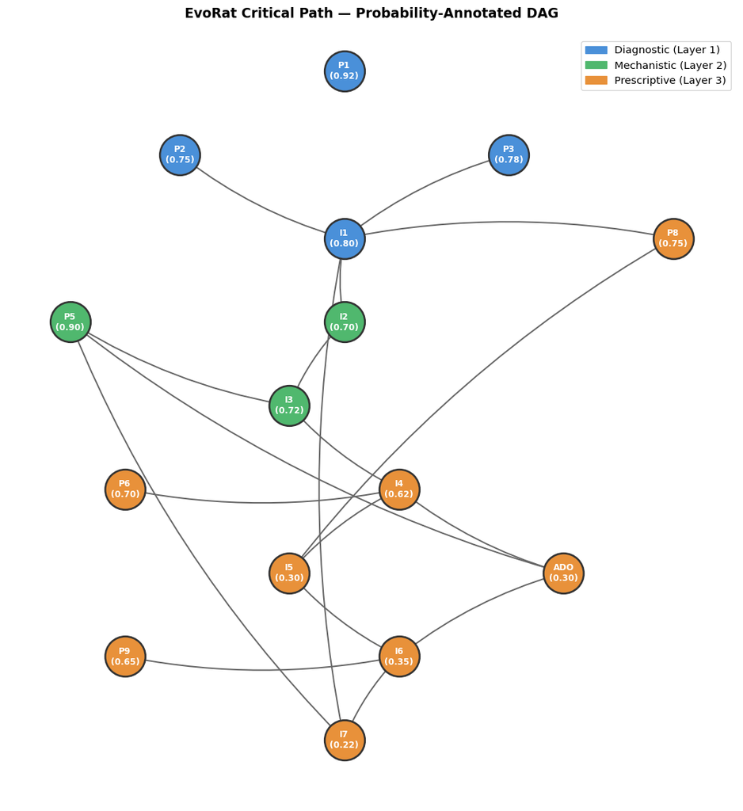

Figure 1: EvoRat Critical Path — Probability-Annotated DAG (simplified). This figure visualizes 15 critical-path nodes from the full BayesDown model (~47 nodes, H.3). Nodes are color-coded by layer: blue (diagnostic), green (mechanistic), orange (prescriptive/conclusion). I4 represents the paper’s central novel claim (comparability creates accuracy pressure, 0.62); the adoption gap (ADO, 0.30) is the primary bottleneck between mechanism effectiveness and transformation. Some edges represent transitive connections through intermediate nodes not shown (e.g., P8 reaches I5 through AMTAIR_Changes_Risk_Structure; see H.3 for full dependency structure).

### H.3 BayesDown Map – Critical Path Nodes

```
===
title: EvoRat -- BayesDown Probabilistic Extension
version: 2.0
date: 2026-03-03
calibration: Independent prose reconstruction + skeleton warrant assessment
note: All probabilities are author assessments; ranges are 80% credible intervals
===

/* ================================================================
   ROOT NODES (priors only -- no parents in dependency graph)
   These nodes have no incoming edges; their priors are unconditional.
   ================================================================ */

/* P1 prior 0.92: Well-evidenced Kuhnian diagnosis (E1, E2, E6).
   Paper presents this with high confidence, supported by 4
   operationalized criteria with observable evidence. The Kuhnian
   diagnosis is the paper's most confident claim. */
[P1]: AI governance exhibits several Kuhnian pre-paradigmatic symptoms. { "instantiations": ["p1_TRUE", "p1_FALSE"], "priors": { "p(p1_TRUE)": "0.92", "p(p1_FALSE)": "0.08" }, "range": "[0.85-0.96]" }

/* P2 prior 0.75: Selection insufficiency is plausible but no direct test. */
[P2]: Existing selection mechanisms insufficient for accuracy. { "instantiations": ["p2_TRUE", "p2_FALSE"], "priors": { "p(p2_TRUE)": "0.75", "p(p2_FALSE)": "0.25" }, "range": "[0.60-0.85]" }

/* Distinctive_Severity prior 0.85: Strong assertion, 4 distinct features
   each well-argued. */
[Distinctive_Severity]: AI governance's pre-paradigmatic condition is distinctively severe. { "instantiations": ["severity_HIGH", "severity_LOW"], "priors": { "p(severity_HIGH)": "0.85", "p(severity_LOW)": "0.15" }, "range": "[0.75-0.92]" }

/* P4 prior 0.80: The paper acknowledges this is analogical but argues the
   structural parallel is productive. Footnote hedging lowers confidence
   slightly from the confident presentation. */
[P4]: Cultural evolution theory applies to AI safety arguments. { "instantiations": ["p4_TRUE", "p4_FALSE"], "priors": { "p(p4_TRUE)": "0.80", "p(p4_FALSE)": "0.20" }, "range": "[0.70-0.88]" }

/* ================================================================
   DEPENDENT NODES: DIAGNOSTIC AND MECHANISTIC LAYERS
   ================================================================ */

/* P3 prior 0.78: Anti-correlation claim supported by E3 (case studies:
   DeepSeek cascade + P(doom) underdetermination). Paper's "central
   conceptual contribution" -- now grounded in two empirical cases rather
   than the false precision-to-vagueness claim. Prior unchanged: new
   evidence is at least as strong as old (arguably stronger -- observable
```

[output cut: 89 more lines]

```
  + [I5]
  + [Adoption_Achieved]
  + [P9]

/* I7 (THESIS_Enables_Transformation) -- the MAIN CONCLUSION.
   3-state: transformation_ACHIEVED / transformation_ENABLED_NOT_ACHIEVED /
   transformation_NOT_ENABLED.
   This directly captures the paper's "enables vs. transforms" distinction.
   Parents: I6 (decomposition works), Paradigm_Will_Form (urgency),
   Self_Perpetuating_Loop (problem severity -- stronger problem = more
   value in solution). */
[I7]: AMTAIR enables (and plausibly achieves) transformation of AI governance. { "instantiations": ["transformation_ACHIEVED", "transformation_ENABLED_NOT_ACHIEVED", "transformation_NOT_ENABLED"], "priors": { "p(transformation_ACHIEVED)": "0.22", "p(transformation_ENABLED_NOT_ACHIEVED)": "0.43", "p(…
  + [I6]
  + [P5]
  + [I1]
```

### H.4 Defense, Scoping, and Evidence Nodes (Simplified Priors)

```
/* ================================================================
   Defense nodes -- prior represents strength of objection-preemption
   ================================================================ */
[D1]: Kuhnian objections manageable. { "instantiations": ["d1_TRUE", "d1_FALSE"], "priors": { "p(d1_TRUE)": "0.80", "p(d1_FALSE)": "0.20" } }
[D2]: Hallucination problem addressable via defense-in-depth. { "instantiations": ["d2_TRUE", "d2_FALSE"], "priors": { "p(d2_TRUE)": "0.65", "p(d2_FALSE)": "0.35" } }
[D3]: Anti-gaming mechanisms effective against Goodhart risk. { "instantiations": ["d3_TRUE", "d3_FALSE"], "priors": { "p(d3_TRUE)": "0.55", "p(d3_FALSE)": "0.45" } }
[D4]: Values objection addressed via revelation not resolution. { "instantiations": ["d4_TRUE", "d4_FALSE"], "priors": { "p(d4_TRUE)": "0.70", "p(d4_FALSE)": "0.30" } }
[D5]: Adoption barriers addressable via funder requirements. { "instantiations": ["d5_TRUE", "d5_FALSE"], "priors": { "p(d5_TRUE)": "0.50", "p(d5_FALSE)": "0.50" } }

/* ================================================================
   Scoping nodes -- prior represents claim-limitation adequacy
   ================================================================ */
[S1]: Scoped to empirical/modeling layers only. { "instantiations": ["s1_TRUE", "s1_FALSE"], "priors": { "p(s1_TRUE)": "0.90", "p(s1_FALSE)": "0.10" } }
[S2]: Theoretical contribution independent of adoption. { "instantiations": ["s2_TRUE", "s2_FALSE"], "priors": { "p(s2_TRUE)": "0.85", "p(s2_FALSE)": "0.15" } }
[S3]: Cascade analysis is mechanism-neutral (HOW not WHETHER). { "instantiations": ["s3_TRUE", "s3_FALSE"], "priors": { "p(s3_TRUE)": "0.90", "p(s3_FALSE)": "0.10" } }
[S4]: No empirical validation -- presented as hypothesis. { "instantiations": ["s4_TRUE", "s4_FALSE"], "priors": { "p(s4_TRUE)": "0.95", "p(s4_FALSE)": "0.05" } }
[S5]: Five AMTAIR-specific falsifiable predictions specified. { "instantiations": ["s5_TRUE", "s5_FALSE"], "priors": { "p(s5_TRUE)": "0.85", "p(s5_FALSE)": "0.15" } }
[S6]: Five Rich-derived falsifiable predictions specified. { "instantiations": ["s6_TRUE", "s6_FALSE"], "priors": { "p(s6_TRUE)": "0.80", "p(s6_FALSE)": "0.20" } }

/* ================================================================
   Evidence nodes -- prior represents evidential strength
   ================================================================ */
[E1]: Four Kuhn symptoms with examples. { "instantiations": ["e1_TRUE", "e1_FALSE"], "priors": { "p(e1_TRUE)": "0.85", "p(e1_FALSE)": "0.15" } }
[E2]: Massive parameter disagreement documented. { "instantiations": ["e2_TRUE", "e2_FALSE"], "priors": { "p(e2_TRUE)": "0.90", "p(e2_FALSE)": "0.10" } }
[E3]: DeepSeek cascade + P(doom) underdetermination case studies. { "instantiations": ["e3_TRUE", "e3_FALSE"], "priors": { "p(e3_TRUE)": "0.85", "p(e3_FALSE)": "0.15" } }
[E4]: Carlsmith power-seeking extraction as illustration. { "instantiations": ["e4_TRUE", "e4_FALSE"], "priors": { "p(e4_TRUE)": "0.80", "p(e4_FALSE)": "0.20" } }
[E5]: Cascade reversal (Hinton example). { "instantiations": ["e5_TRUE", "e5_FALSE"], "priors": { "p(e5_TRUE)": "0.85", "p(e5_FALSE)": "0.15" } }
[E6]: Pre-marginalist economics parallel. { "instantiations": ["e6_TRUE", "e6_FALSE"], "priors": { "p(e6_TRUE)": "0.70", "p(e6_FALSE)": "0.30" } }
[E7]: Technical precedents (Buckingham Shum, Prokudin, Bhatia). { "instantiations": ["e7_TRUE", "e7_FALSE"], "priors": { "p(e7_TRUE)": "0.75", "p(e7_FALSE)": "0.25" } }
```

### H.5 Sensitivity Analysis

Computing marginal probabilities by propagating through the critical path chain:

| Node | Prior | Key Driver | Sensitivity |
| --- | --- | --- | --- |
| P1 | 0.92 | E1, E2, E6 (documented symptoms) | Low – near ceiling; well-evidenced |
| P3 | 0.78 | P4 + Distinctive_Severity (cultural evolution + severity) | Moderate – central conceptual contribution |
| I1 | 0.80 | P2 x P3 x P8 joint (all needed) | **High** – breaks if any selection/cascade claim fails |
| I3 | 0.72 | P5 (forcing function, 0.90) | Low – forcing function is robust |
| I4 | 0.62 | P6 (architecture, 0.70) + P3 (anti-correlation) | **High** – core prescriptive mechanism, no empirical validation |
| Adoption | 0.30 | I4 (accuracy pressure) + P5 (forced convergence) | **Highest** – the single largest source of uncertainty |
| I5 | 0.30 (substantial) | I4 + Risk_Structure + Defenses (joint) | **High** – 3-parent node, adoption-gated |
| I7 | 0.22 (achieved) | I6 + P5 + I1 (full chain propagation) | **Highest** – entire intervention layer concentrates here |

**Top uncertainty drivers** (ranked by estimated swing on I7; swing values are approximate single-variable sensitivity estimates, not formal propagation through the full CPT structure):

The node with highest leverage for strengthening the argument is I4 (accuracy pressure mechanism), where empirical evidence from pilot deployments would most improve the overall probability chain. The adoption node has higher absolute swing but is harder to address within the paper itself – it depends on real-world institutional dynamics.

### H.6 Cross-Paper Dependencies

Several nodes in the BayesDown model are sensitive to results from the companion papers in this thesis: Meyer (2025c) (EpiOrg, on epistemic contamination in organizations) and Meyer (2025d) (PhilOfEcon, on philosophy of economics methodology). This section traces how acceptance or rejection of key companion arguments would shift probability estimates.

**EpiOrg dependencies.** Two nodes are directly affected by the contamination analysis:

- *M3 (prediction tracking / accountability, mechanism node)*. M3 relies on contamination-free measurement. If EpiOrg’s contamination prevention framework is rejected – i.e., if epistemic contamination cannot be reliably prevented in organizational settings – the prediction tracking mechanism becomes unreliable as a selection signal. Estimated shift: M3 effectiveness drops substantially, which propagates through I4 and I5. Net effect on I7: P(transformation_ACHIEVED) drops from ~0.22 to ~0.17.
- *D3 (anti-gaming mechanisms, prior: 0.55)*. Conversely, if EpiOrg’s contamination taxonomy is validated, the five anti-gaming mechanisms gain additional theoretical grounding: contamination types map onto gaming vectors, enabling targeted countermeasures. Estimated shift: D3 rises from 0.55 to ~0.70, which strengthens Defenses_Hold.

**PhilOfEcon dependencies.** Two nodes are sensitive to the level-separation framework:

- *P9 (disagreements are empirical not normative, prior: 0.65)*. If PhilOfEcon’s epistemic/procedural/institutional level-separation is accepted, it provides independent support for the decomposition claim: apparent value disagreements often dissolve when analyzed at appropriate levels. Estimated shift: P9 rises from 0.65 to ~0.80.
- *D4 (values objection defense, prior: 0.70)*. If PhilOfEcon’s model pluralism argument is accepted, the “reveals rather than resolves” defense (Section VI.3) is strengthened: AMTAIR need not impose a single model but can maintain pluralism while making disagreements explicit. Estimated shift: D4 rises from 0.70 to ~0.85.

**Aggregate effect on I7.** Propagating these shifts through the critical path: accepting both companion papers would improve P9 (0.65 to 0.80) and strengthen defenses, yielding an overall shift in P(transformation_ACHIEVED) from ~0.22 to approximately 0.28 – a meaningful but not transformative improvement. The primary channel is through P9 to I6 (direct parent) rather than through the defense nodes (indirect effect). This confirms that the prescriptive layer’s weakness is structural (adoption uncertainty) rather than solely dependent on companion results.

### H.7 Comparison with Carlsmith Extraction

Appendix A.3 presents the Carlsmith (2022) power-seeking extraction as an illustration of the BayesDown methodology applied to a sequential risk argument. Comparing the two extractions highlights structural differences in how the arguments are organized:

[output not shown]

Three structural implications emerge. First, Carlsmith’s sequential chain means that *every* node is on the critical path – weakening any single premise reduces the overall probability proportionally. EvoRat’s DAG structure means some nodes (e.g., scoping nodes S1-S6) constrain scope without affecting the probability chain, while others (I4, Adoption_Achieved) directly feed the conclusion. Second, EvoRat’s defensive and suppressed-premise nodes model aspects invisible in the Carlsmith extraction: the adversarial structure of academic argument, where objections and their rebuttals shape robustness, and the unstated assumptions that could undermine the argument if violated. Third, the bottleneck pattern (Adoption = 0.30) versus the distributed pattern (each Carlsmith node approximately 0.50-0.70) suggests different intervention strategies: for Carlsmith, marginal improvement to *any* node helps roughly equally; for EvoRat, targeted improvement to the adoption bottleneck and accuracy-pressure mechanism (I4) has disproportionate effect.

## Acknowledgements

I thank Prof. Patricia Rich for sustained engagement with this project across multiple drafts. Her feedback reshaped the paper’s architecture, and her published work on epistemic conformity and cascade dynamics (Rich, 2025) supplied the analytical framework for Sections III and IV. Her willingness to advise an unconventional project at the intersection of AI governance and evolutionary epistemology made the paper possible. I also thank the broader AI safety research community whose discourse provided both subject matter and motivation, and friends and family whose feedback helped clarify arguments that expertise had rendered invisible. AMTAIR was developed as the author’s master thesis at the University of Bayreuth, supervised by Prof. Timo Speith; this paper and its companions (Meyer, 2025d, 2025c) explore specific theoretical dimensions of the project. Any remaining errors are my own.

## CITATION VERIFICATION TABLE

| Citation ID | Source | Sections Used | Quotations Verified Against | Notes |
| --- | --- | --- | --- | --- |
| Kuhn 1962 | Kuhn, T. *Structure of Scientific Revolutions* | I.3, App.B | Standard reference — no verification needed | Classic text |
| Bostrom 2014 | Bostrom, N. *Superintelligence* | Throughout | Standard reference | Major AI safety work |
| Boyd & Richerson 2004 | Boyd, R. & Richerson, P. *Not By Genes Alone* | III.1, App.C | Standard reference | Cultural evolution foundation |
| Buckingham Shum 2024 | Shum, S. “Generative AI for Critical Analysis” | II.3.2, IV.4, VI.1 | GenAIToolsCognitiveOffloading_S.Shum.md | Validates ArgDown extraction |
| Hendrycks 2023 | Hendrycks, D. “Natural Selection Favors AIs over Humans” | III.2 | ResearchReport_AMTAIREvolution/Updated Literature Review, project search | Core evolutionary framework |
| Rich 2022 | Rich, P. “Hidden Costs of Epistemic Conformity” (BJPS) | III.5 | Patricia’s Paper (html artifact) | Course material |
| Baimuratov et al. 2025 | Baimuratov, Lisanyuk & Prokudin “Dispute Resolution in Peer Review” | V.1 (fn), App.E | Dispute_Resolution_in_Peer_Review (new literature) | Formal argumentation |
| Bhatia & Sukthankar 2024 | Bhatia & Sukthankar “Moderating Democratic Discourse with LLMs” | V.1 (fn) | SBP-BRiMS 2024 (Springer LNCS vol 14972) | Policy visualization |
| Voigt 2014 | Voigt, C. ArgDown (COMMA 2014) | II.3.2 | ArgDownStackedInterface_C.Voigt.md | ArgDown creator |
| Carlsmith 2022 | Carlsmith, J. “Is Power-Seeking AI an Existential Risk?” | II.3.4 | PY_Submitted_MAThesis (references) | Major safety argument |
| ETO Research Almanac 2024 | “AI Safety” topic page | II.1 | https://almanac.eto.tech/topics/ai-safety/ | Private sector statistics |
| Müller & Bostrom 2016 | Timeline surveys | I.3, V.2 (fn) | Referenced Updated Literature Review/Table | Expert survey data |
| Grace et al. 2018 | AGI timeline study | I.3, V.2 | Referenced Updated Literature Review/Table | Expert predictions |
| Mowshowitz 2025 | Zvi “DeepSeek: Don’t Panic” (Substack) | V.1 | thezvi.substack.com | DeepSeek analysis |
| DeepSeek-AI 2025 | DeepSeek-R1 technical report (arXiv 2501.12948) | V.1 (fn) | arXiv:2501.12948 | Architecture details |
| Field 2025 | “Why do Experts Disagree on P(doom)?” (arXiv 2502.14870) | V.2 | arXiv:2502.14870 | Expert disagreement survey |
| Dung 1995 | Dung, P. Abstract Argumentation | App.E | Standard reference in argumentation theory | Foundational AAF |
| Pea 1985 | Pea, R. Cognitive tools | IV.4 | Cited via Buckingham Shum 2024 | Pedagogic/pragmatic distinction |
| Christiano 2018 | Christiano, P. Prosaic alignment | Various | Referenced in project materials | Major alignment approach |
| Meyer 2025 | Meyer, V.J. MA Thesis: AMTAIR | II.3.1, II.3.2 | Author’s thesis | BayesDown specification |
| Brundage et al. 2020 | Brundage, M. et al. “Trustworthy AI Development” | VI.1 | arXiv:2004.07213 | Verification mechanisms |
| Clarke et al. 2022 | Clarke, S. et al. “Modeling Transformative AI Risks (MTAIR)” | IV.1 (P12) | arXiv:2206.09360 | AMTAIR predecessor project |

## Footnotes

[^1]: When I refer to “AI safety and governance,” I mean primarily the *research discourse* — academics, think tank researchers, and technical safety specialists building intellectual infrastructure for managing transformative AI. This paper focuses on this community rather than public debate or corporate communications, though insights may transfer.
[^2]: AMTAIR is the author’s forthcoming master thesis project (Meyer, 2025a) at the University of Bayreuth, building on the manual predecessor MTAIR (Clarke et al., 2022). It could be seen as infrastructure analogous to what controlled experiments provide for chemistry or mathematical formalization provides for economics. The companion papers in this series — Meyer (2025c) and Meyer (2025d) — analyze complementary aspects of AMTAIR’s design.
[^3]: Kuhn uses “paradigm” multiply, but the relevant meaning here is “universally recognized scientific achievements that for a time provide model problems and solutions to a community of practitioners.” This paper employs Kuhn’s framework rather than alternatives — Lakatos’s research programmes or Laudan’s research traditions — because Kuhn’s concept of pre-paradigmatic science most precisely captures AI governance’s condition: not a field with competing but *commensurable* research programmes (Lakatos), nor one with traditions that can borrow heuristic devices across boundaries (Laudan), but one where researchers lack the shared foundations that would make inter-programme comparison possible in the first place. The diagnosis would survive translation into Lakatosian terms (AI governance lacks a “hard core” around which protective belts could form), but the Kuhnian framing is more parsimonious for the argument at hand. See Appendix B for extended Kuhnian analysis.
[^4]: In the past industry groups such as the tobacco industry and fossil fuels lobbies have used “distraction” tactics and calls for “definitive” proof and conclusive evidence to slow down scientific progress and sabotage political action. Practices that could be dangerous precedents for what to expect from AI industry lobbies.
[^5]: These claims can be operationalized. Pre-paradigmatic status predicts low bibliographic coupling between major research programs, low inter-method agreement on core questions, and absence of standardized benchmarks. What would falsify this? Citation integration across programs, methodological convergence, or field-wide benchmark adoption. Currently none obtain.
[^6]: This is Kuhn’s most serious objection to extending his framework beyond natural science: paradigm formation requires a selection mechanism that favors accuracy, and governance — unlike physics or chemistry — may lack adequate ones. The resolution — that AMTAIR could *strengthen* such mechanisms — is the paper’s core intellectual contribution (Section IV). Two further Kuhnian objections are more manageable: “Is AI governance a science?” is resolved by scoping the claim to AI governance’s *epistemic* layers — the paper doesn’t claim governance is a Kuhnian science, only that its empirical and modeling dimensions exhibit pre-paradigmatic dynamics. “Has AI governance ever had a paradigm, or is it not-yet-science?” is resolved by the forcing function: regardless of history, a paradigm *will* form.
[^7]: AI governance is a composite field with multiple epistemic layers: empirical (how fast are capabilities advancing?), modeling (what causal structures connect capabilities to risks?), policy (what regulatory frameworks work?), and normative (how much risk is acceptable?). This paper’s claims target the empirical and modeling layers, which exhibit pre-paradigmatic dynamics amenable to formalization. The normative layer is permanently pluralistic — and appropriately so. AMTAIR addresses empirical/modeling disagreements, not normative ones.
[^8]: A historical parallel illustrates the diagnosis: pre-marginalist economics (1750–1870) exhibited similar symptoms — competing schools (mercantilists, physiocrats, classicals), fundamental debates over value theory (labor theory vs. subjective theory vs. cost-of-production theory), accusations that economics was irreducibly normative and could never achieve scientific status. Yet the marginalist revolution of the 1870s showed that formal mathematical tools could separate empirical claims from evaluative ones, enabling paradigm formation despite the field’s normative dimensions. The parallel is instructive: economics didn’t become value-free, but formalization enabled researchers to distinguish “X causes Y” (testable) from “Y is desirable” (evaluative). AMTAIR could catalyze analogous transformation in AI governance. The comparison with pre-paradigmatic fields extends further: pre-Lavoisier chemistry (canonical Kuhnian case) converged via definitive experiments — but AI governance’s “experiments” are unrepeatable deployment decisions. Economics achieved partial paradigm formation despite normative contamination and weak natural feedback — the closest structural analog to AI governance. Psychology remains pre-paradigmatic in several sub-fields even after a century, suggesting that without deliberate intervention, pre-paradigmatic conditions can persist indefinitely.
[^9]: This isn’t claiming arguments are literally organisms. The evolutionary framework is productive because cultural transmission exhibits analogous dynamics — variation through innovation, differential replication based on fitness, cumulative change — but operates much faster, permits intentional design, and allows horizontal transmission. See Appendix C.
[^10]: An alternative diagnosis: AI safety might exhibit “post-normal science” (Funtowicz & Ravetz, 1993) characteristics where full convergence is impossible because disagreements are value-based. Even so, AMTAIR can separate epistemic from normative disagreement, identifying where differences reduce to facts (addressable through evidence) versus values (requiring negotiation).
[^11]: Technical safety researchers focus on alignment and interpretability; policy specialists bring institutional expertise but often lack technical depth; ethicists contribute conceptual rigor but may lack both; industry actors hold private capability information; national security actors operate under different classification and incentive structures.
[^12]: Why Bayesian networks? (1) Native uncertainty handling — unlike classical logic, BNs represent degrees of belief naturally; (2) explicit causal structure — unlike pure statistical models, BNs encode directional relationships; (3) compositional inference — BNs enable systematic updating; (4) decision science standard — BNs are established in policy analysis and risk assessment.
[^13]: See Appendix A for full technical specification including ArgDown/BayesDown syntax, extraction pipeline code, and implementation details.
[^14]: Complete Carlsmith extraction with probability specifications appears in Appendix A.
[^15]: The value of such formalization extends beyond transparency. Formal methods yield stronger notions of trust than possible with intuition or empirical methods such as benchmarking (Singh & Chawla, 2025), and engagement with Carlsmith’s argument has revealed persistent ambiguity between conjunctive and disjunctive framing of the risk premises (Carlsmith, 2022; see Soares, 2021) — ambiguity that explicit Bayesian network extraction eliminates.
[^16]: Cultural evolution differs from genetic evolution in speed (years not millennia), intentionality (guided variation possible), transmission modes (horizontal, oblique, vertical), and recombination (unlimited — any ideas can merge). See Appendix C for extended framework.
[^17]: Arguable examples: Bostrom’s treacherous turn or Yudkowsky’s recursive self-improvement
[^18]: This extends Hendrycks’s framework from entity-level to idea-level competition. The extension is analogical — arguments don’t literally reproduce — but the structural parallel is productive for understanding discourse dynamics.
[^19]: Additional pressures compound these: media pressures favor vividness over accuracy (“AI is a bubble about to pop” makes headlines; careful methodological analysis does not), and political pressures reward timely framing over careful analysis. The combined effect across all five pressure types: current environment systematically rewards memetic fitness far more than epistemic fitness and truth tracking.
[^20]: Each argument also implicitly maps to a point in policy preference space: Yudkowsky’s (2008) arguments recommend immediate moratorium; Christiano’s (2018) recommend parallel capability-safety research; Hanson’s (2013) recommend minimal regulation. AMTAIR makes these mappings explicit, enabling systematic evaluation. See Appendix D for the formal framework.
[^21]: This is why conformity’s evolutionary cost is hidden: conformists achieve higher *expected* fitness in any given round, but their *variance* across rounds is higher because aggregate risk means their failures are correlated — when a reverse cascade occurs, all conformists fail simultaneously. Selection penalizes this variance. The non-conformist strategy, despite lower expected returns, survives because its failures are independent — when one non-conformist errs, others need not. Over evolutionary time, the variance penalty outweighs the mean advantage. Non-conformist success during reverse cascades disproportionally and differentially benefits the evolutionary reproductive fitness.
[^22]: This also creates conditions for moral hazards if blameworthiness for negative outcomes is based not on the evaluation of prevention and safety measures but instead blameworthiness is measured by divergence or adherence to (potentially misguided, flawed) consensus.
[^23]: Rich’s Result 2, applied to discourse
[^24]: Rich’s broader research program in social epistemology and philosophy of science emphasizes that rationality is environment-relative: what counts as rational depends on the structure of feedback and selection.
[^25]: This is not a claim about whether existential risk concerns are well-founded (I believe they are) — the analysis concerns HOW positions spread, not WHETHER they are correct. The same cascade dynamics could sustain either accurate or inaccurate consensus; the point is that cascade-driven convergence cannot distinguish the two.
[^26]: Consider the debate over AI development speed: apparent value disagreement (“how much risk is acceptable?”) often reduces to modeling disagreement (“what causal mechanism connects capability scaling to misalignment risk?”). Formalization reveals that substantial common ground can be hidden beneath incommensurable frameworks.
[^27]: Notice the value of being aware when normative disagreements underlie debates; it allows participants to understand which approaches hold promise and which do not.
[^28]: The materials science parallel holds: comparability creates the possibility of accuracy-based selection; institutional requirements (Section VII) shape virtuous competition.
[^29]: The longest-horizon claims in AI governance (e.g., $P(\text{existential catastrophe by 2100})$) operate on timescales that defeat empirical verification within any policy-relevant window; by the time we could verify them, the information would be useless. This afflicts all tail-risk interventions, from nuclear nonproliferation to pandemic preparedness. The epistemically honest response is not to abandon long-horizon reasoning but to evaluate interventions by their effect on *intervening variables* whose accuracy is independently testable: does formalization improve probability calibration on 2–5 year questions? Does model comparison identify genuine cruxes? Does prediction tracking create accountability? If AMTAIR succeeds on these measurable intermediaries, the case for its value on longer horizons rests on the plausibility of the causal chain connecting them — a chain this paper has tried to make explicit and criticizable rather than implicit and unfalsifiable.
[^30]: This also raises a deeper worry: that formal modeling promises coordination benefits while producing sophisticated-looking outputs without genuine epistemic grounding. The complementarity argument below addresses both versions of the concern.
[^31]: A technical challenge: Bayesian networks require conditional probability tables (CPTs) that authors rarely provide fully. AMTAIR must “fill in blanks” using defaults or LLM-inferred values, risking hallucinated precision. Mitigations: sensitivity analysis identifying which entries drive variance, uncertainty propagation using distributions rather than point estimates, repeated independent extractions to approximate convergence, and source-constrained extraction mandating transparency about what’s extracted versus assumed.
[^32]: The use of temporal embargos and other techniques to achieve this is detailed in Meyer (2025c).
[^33]: Of course there is still a signal if many authors, forecasters etc. converge on the same or similar models but the strength of such signals depends crucially on the *independence* (and scrutiny) underlying the convergence.
[^34]: The “Sputnik moment” framing itself illustrates cascade propagation: the analogy spread through policy discourse within days, anchoring interpretation before technical assessment could catch up. The DeepSeek-R1 technical report (DeepSeek-AI, 2025) documents the architecture (mixture-of-experts with 671B total / 37B active parameters, reinforcement learning for reasoning); these capabilities, while impressive, build on published techniques available to any well-resourced lab.
[^35]: The market’s delayed reaction is itself diagnostic: a rational response to new information would have occurred at model release, not a week later in a social media amplified feedback loop.
[^36]: For anyone tracking open-source AI development, the information content of DeepSeek’s model was near-zero. Fast-following is fundamentally easier than frontier research; Chinese ML talent runs deep; export control workarounds were known; the specific techniques (MoE architecture, distillation from frontier models, cost-efficient training) had been documented in the open literature. As Mowshowitz (2025) observed, DeepSeek was “impressive as a lab… but still on the order of eight months behind.” The feasibility of extracting and structuring such technical claims at scale is independently validated: Buckingham Shum (2024) demonstrate generative AI for critical analysis of arguments, suggesting the AMTAIR counterfactual rests on demonstrated capabilities, not speculation.
[^37]: The FLI pause letter (2023) illustrates the same cascade-then-fragmentation pattern: 30,000+ signatures accumulated through social proof effects, with epistemic evaluation lagging behind memetic spread, followed by fragmentation into “pause is necessary” versus “pause is counterproductive” camps with no convergence mechanism. Bhatia & Sukthankar (2024) independently approached exactly this problem, using LLMs to structure fragmented policy discourse and reveal hidden consensus, suggesting both demand for and feasibility of computational discourse structuring.
[^38]: The AMTAIR counterfactual assumes formal argumentation can scale to real disputes. This is not merely theoretical: Prokudin et al. (2024) demonstrate computationally feasible abstract argumentation frameworks for peer review, providing independent validation that structured formal analysis operates on genuine epistemic disagreements. Their AAF approach complements AMTAIR’s Bayesian networks, handling logical structure where AMTAIR handles probabilistic quantification (see Appendix E for formal semantics).
[^39]: Survey means cluster near 14% with medians around 5% (Grace et al., 2024).
[^40]: The range of estimates is historically anomalous. Early AI safety discourse was notably *more* specific: Bostrom (2014) specified detailed conditions under which intelligence explosion would occur, with concrete capability thresholds that made claims testable, exposing them to reputational risk when timelines shifted. The current dispersion represents not merely disagreement but a failure of the field’s epistemic infrastructure to produce convergence over two decades of accumulating evidence. Expert predictions are systematically overconfident, with accuracy rates between 14% and 50% depending on domain and forecast horizon (see review in Savage et al., 2021); specific claims bear asymmetric downside risk (Tetlock, 2005); accountability structures rarely focus on predictive accuracy (Langvatn & Holst, 2024), yet the selection environment offers no comparable penalty for vagueness.
[^41]: Yudkowsky’s high estimate cascades through rationalist communities, LeCun’s zero cascades through “accelerationist” twitter.
[^42]: Field (2025) reports that researchers in the “controllable tool” cluster were largely unfamiliar with arguments central to the “uncontrollable agent” framework (e.g., mesa-optimization, deceptive alignment). This is consistent with *both* cascade dynamics (within each prestige community, certain concepts propagate while others are filtered out through the same social transmission dynamics that drive BHW cascades (Bikhchandani et al., 1992)) *and* independent analysis from different conceptual foundations. Concept-unfamiliarity could reflect cascade filtering (certain ideas propagate within prestige communities while others are screened out) or genuinely different starting points; the data alone cannot distinguish these.
[^43]: The trajectory from Müller & Bostrom (2016)’s early surveys through Grace et al. (2018) to Grace et al. (2024) shows accelerating compression: median HLMI estimates moved from approximately 2050 (2016) to 2061 (2018) to 2047 (2023). Task-level estimates compressed even more dramatically. However, individual task-level medians shifted only approximately one year on average, suggesting the headline compression may be driven by changes in aggregation or framing rather than uniform updating, itself suggestive of cascade dynamics rather than independent evidence evaluation.
[^44]: For example, if one model literally has no node for deceptive alignment while another’s central structure depends on it, that is a structural difference, not merely a quantitative one. If both models share the same structure but differ on parameter values, that is evidence for independent analysis from shared foundations. The distinction matters because structural disagreement suggests cascade filtering, while parametric disagreement suggests genuine uncertainty.
[^45]: Secondary challenges include ambiguity in natural language (requiring interpretive judgment) and computational complexity of large networks (requiring hierarchical decomposition). These are real and should not be underestimated but tractable engineering challenges rather than fundamental threats.
[^46]: Of course by now multiple generations outdated but similar problems might persist.
[^47]: For example, when Bostrom discusses intelligence explosion, does he assume recursive self-improvement as a premise or a conclusion?
[^48]: Source linking means every extracted claim references specific text spans, creating a verifiable audit trail. Human validation provides expert review of high-stakes extractions, particularly for policy-relevant models. Multiple independent iterations reveal inconsistencies: genuine relationships appear consistently across extractors while hallucinated ones vary. Adversarial review enables community challenge of suspect dependencies.
[^49]: Some structural errors will inevitably persist; the question is whether rates are low enough for useful comparison. Early evidence from manual extraction suggests core structural features are robust while peripheral relationships are more variable.
[^50]: Mathematical economics produced models of stunning sophistication while encoding often unrealistic assumptions and losing track of when they no longer hold; the parallels to AMTAIR are direct.
[^51]: In detail: prediction tracking ties reputation to accuracy through publicly verifiable model predictions. Adversarial validation red-teams models before publication. Complexity penalties prefer simpler models when equally predictive. Gaming detection flags suspicious patterns such as structural isomorphism with high-status predecessors, always-bracketing probability ranges, or complexity without prediction. Independent audits provide third-party verification for high-stakes extractions. A subtler Goodhart risk: selection for simplicity could marginalize genuinely complex arguments. If formalization favors clean networks, nuanced positions requiring 50 nodes lose to 5-node strawmen. Mitigation requires interfaces making complexity navigable: summary views, hierarchical expansion, sensitivity analyses showing which complexity matters. Additional secondary challenges include legitimacy and inclusion (formalization might marginalize non-technical voices, mitigated by open-source tools, accessible visualization, pluralist governance) and dynamic argument updating (models evolve, mitigated by versioning and change tracking).
[^52]: In this case the author, Carlsmith (2022), has worked on verifying the correct extraction with MTAIR before.
[^53]: Every extracted node traces to specific text spans, enabling audit of interpretive choices against source material.
[^54]: This parallels how welfare economics separates positive from normative analysis: identifying the Pareto frontier (empirical) is valuable even when the choice *along* the frontier (normative) remains contested. AMTAIR aims to map analogous frontiers in governance space.
[^55]: Comparing three models individually is somewhat useful; comparing three hundred reveals structural patterns. The value is superlinear in participation.
[^56]: Analogously, game theory illuminates strategic interaction regardless of whether actors consciously apply game-theoretic reasoning. The analytical framework generates insight independent of implementation.
[^57]: Mandating formal model submission alongside prose arguments, as NSF data management plans transformed research practices, could trigger network effects from which voluntary adoption compounds.
[^58]: Detailed, illustrated pathway: Early phase (years 1–2): proof-of-concept, 5–10% adoption, tool refinement. Tipping point (years 3–4): funder requirements, 30–50% adoption, 100+ models. Equilibrium (years 5+): standard practice. Success metrics: model convergence rates, prediction accuracy vs. baselines, cross-community collaboration, participation diversity. Pitfalls: institutional capture (mitigate via open-source governance), metric gaming (multiple measures), premature standardization (versioning, sunset clauses).
[^59]: An irony: AMTAIR adoption may depend on prestige dynamics it aims to transcend; early adoption by high-status researchers creates demonstration effects. This is strategic realism: using prestige cascades to establish infrastructure that ultimately reduces prestige dominance.
[^60]: At the individual level, formalization becomes a career signal (“my model predicts better than alternatives”) and practically useful. At the group level, a collaboration tool (“our lab’s models interface with others’”). At the institutional level, a funder requirement (“grant proposals must include formal model specifications”).
[^61]: The analogy has important limits. Wolves exert hard constraints; elk that ignore them die. AMTAIR creates a metric the ecosystem could disregard. Funder requirements are therefore essential: coupling resource allocation to accuracy metrics gives AMTAIR “teeth.” Additional limits: The Yellowstone ecosystem was relatively stable otherwise; AI governance operates in rapid flux; ecological interventions are reversible while institutional path dependencies are less so.
[^62]: To understand the intuition behind the claim that this will inevitably happen, consider the politics after a potential AI-enabled terrorist attack or the like.
[^63]: AMTAIR could enable what might be called an emergent “AI Grand Strategy”, not a single plan but coordination among diverse actors enabled by shared infrastructure. When implicit beliefs become explicit networks, comparison reveals agreements hidden by different language, disagreements traceable to facts versus values, and coordination possibilities given actual belief distributions. Concrete next steps: researchers should attempt AMTAIR extraction of their own arguments; funders should pilot model specification requirements; policymakers should request explicit models underlying recommendations. This paper is itself subject to the dynamics it describes; its spread depends on memetic fitness as much as epistemic merit.
[^64]: This paper is part of a broader research program. The companion epistemology paper (Meyer, 2025c) addresses cascade contamination when incorporating prediction market data into formal models. The companion philosophy of economics paper (Meyer, 2025d) argues that model pluralism is epistemically superior to premature selection, and how AMTAIR enables pluralism without fragmentation.